# Data Selection

```python
import numpy as np
import pandas as pd

import matplotlib.pyplot as plt
import seaborn as sns
sns.set(style='white')

import sklearn
import nltk

import json
import ssl

from collections import Counter
from itertools import chain
from nltk.tokenize import word_tokenize
```

```python
try:
    _create_unverified_https_context = ssl._create_unverified_context
except AttributeError:
    pass
else:
    ssl._create_default_https_context = _create_unverified_https_context

nltk.download('punkt')
```

```
True
```

Load the cleaned data

```python
tmdb_df = pd.read_csv('output/data/tmdb_5000_cleaned.csv')
tmdb_df.head()
```

|  | id | title | budget | cast | crew | genres | keywords | original_language | original_title | overview | popularity | production_companies | production_countries | release_date | revenue | runtime | spoken_languages | vote_average | vote_count |
| --- | --- | --- | --- | --- | --- | --- | --- | --- | --- | --- | --- | --- | --- | --- | --- | --- | --- | --- | --- |
| 0 | 19995 | Avatar | 237000000 | [{"cast_id": 242, "character": "Jake Sully", "... | [{"credit_id": "52fe48009251416c750aca23", "de... | [{"id": 28, "name": "Action"}, {"id": 12, "nam... | [{"id": 1463, "name": "culture clash"}, {"id":... | en | Avatar | In the 22nd century, a paraplegic Marine is di... | 150.437577 | [{"name": "Ingenious Film Partners", "id": 289... | [{"iso_3166_1": "US", "name": "United States o... | 2009-12-10 | 2787965087 | 162.0 | [{"iso_639_1": "en", "name": "English"}, {"iso... | 7.2 | 11800 |
| 1 | 285 | Pirates of the Caribbean: At World's End | 300000000 | [{"cast_id": 4, "character": "Captain Jack Spa... | [{"credit_id": "52fe4232c3a36847f800b579", "de... | [{"id": 12, "name": "Adventure"}, {"id": 14, "... | [{"id": 270, "name": "ocean"}, {"id": 726, "na... | en | Pirates of the Caribbean: At World's End | Captain Barbossa, long believed to be dead, ha... | 139.082615 | [{"name": "Walt Disney Pictures", "id": 2}, {"... | [{"iso_3166_1": "US", "name": "United States o... | 2007-05-19 | 961000000 | 169.0 | [{"iso_639_1": "en", "name": "English"}] | 6.9 | 4500 |
| 2 | 206647 | Spectre | 245000000 | [{"cast_id": 1, "character": "James Bond", "cr... | [{"credit_id": "54805967c3a36829b5002c41", "de... | [{"id": 28, "name": "Action"}, {"id": 12, "nam... | [{"id": 470, "name": "spy"}, {"id": 818, "name... | en | Spectre | A cryptic message from Bond’s past sends him o... | 107.376788 | [{"name": "Columbia Pictures", "id": 5}, {"nam... | [{"iso_3166_1": "GB", "name": "United Kingdom"... | 2015-10-26 | 880674609 | 148.0 | [{"iso_639_1": "fr", "name": "Fran\u00e7ais"},... | 6.3 | 4466 |
| 3 | 49026 | The Dark Knight Rises | 250000000 | [{"cast_id": 2, "character": "Bruce Wayne / Ba... | [{"credit_id": "52fe4781c3a36847f81398c3", "de... | [{"id": 28, "name": "Action"}, {"id": 80, "nam... | [{"id": 849, "name": "dc comics"}, {"id": 853,... | en | The Dark Knight Rises | Following the death of District Attorney Harve... | 112.312950 | [{"name": "Legendary Pictures", "id": 923}, {"... | [{"iso_3166_1": "US", "name": "United States o... | 2012-07-16 | 1084939099 | 165.0 | [{"iso_639_1": "en", "name": "English"}] | 7.6 | 9106 |
| 4 | 49529 | John Carter | 260000000 | [{"cast_id": 5, "character": "John Carter", "c... | [{"credit_id": "52fe479ac3a36847f813eaa3", "de... | [{"id": 28, "name": "Action"}, {"id": 12, "nam... | [{"id": 818, "name": "based on novel"}, {"id":... | en | John Carter | John Carter is a war-weary, former military ca... | 43.926995 | [{"name": "Walt Disney Pictures", "id": 2}] | [{"iso_3166_1": "US", "name": "United States o... | 2012-03-07 | 284139100 | 132.0 | [{"iso_639_1": "en", "name": "English"}] | 6.1 | 2124 |

Convert release date to datetime type

```python
tmdb_df['release_date']=pd.to_datetime(tmdb_df['release_date'], format='%Y-%m-%d', errors='ignore')
```

```python
tmdb_df['release_date']
```

```
0      2009-12-10
1      2007-05-19
2      2015-10-26
3      2012-07-16
4      2012-03-07
          ...
4786   1992-09-04
4787   2011-12-26
4788   2013-10-13
4789   2012-05-03
4790   2005-08-05
Name: release_date, Length: 4791, dtype: datetime64[ns]
```

Convert json strings, e.g. cast, crew, to dataframe type

```python
def to_df(s):
    return pd.DataFrame(json.loads(s))
```

```python
for column in ['cast', 'crew', 'genres', 'keywords',
               'production_companies', 'production_countries', 'spoken_languages']:
    tmdb_df[column]=tmdb_df[column].apply(to_df)
```

```python
tmdb_df.head()
```

|  | id | title | budget | cast | crew | genres | keywords | original_language | original_title | overview | popularity | production_companies | production_countries | release_date | revenue | runtime | spoken_languages | vote_average | vote_count |
| --- | --- | --- | --- | --- | --- | --- | --- | --- | --- | --- | --- | --- | --- | --- | --- | --- | --- | --- | --- |
| 0 | 19995 | Avatar | 237000000 | cast_id character ... | credit_id department gen... | id name 0 28 Actio... | id name 0 1463 cult... | en | Avatar | In the 22nd century, a paraplegic Marine is di... | 150.437577 | name id... | iso_3166_1 name 0 ... | 2009-12-10 | 2787965087 | 162.0 | iso_639_1 name 0 en English 1 ... | 7.2 | 11800 |
| 1 | 285 | Pirates of the Caribbean: At World's End | 300000000 | cast_id character ... | credit_id departmen... | id name 0 12 Adventure 1 14 Fan... | id name 0 ... | en | Pirates of the Caribbean: At World's End | Captain Barbossa, long believed to be dead, ha... | 139.082615 | name id 0 Walt D... | iso_3166_1 name 0 ... | 2007-05-19 | 961000000 | 169.0 | iso_639_1 name 0 en English | 6.9 | 4500 |
| 2 | 206647 | Spectre | 245000000 | cast_id character ... | credit_id department ... | id name 0 28 Action 1 12 Adven... | id name 0 470 ... | en | Spectre | A cryptic message from Bond’s past sends him o... | 107.376788 | name id 0 Columbia Pictur... | iso_3166_1 name 0 ... | 2015-10-26 | 880674609 | 148.0 | iso_639_1 name 0 fr Français 1 ... | 6.3 | 4466 |
| 3 | 49026 | The Dark Knight Rises | 250000000 | cast_id character ... | credit_id departme... | id name 0 28 Action 1 80 Crim... | id name 0 849 ... | en | The Dark Knight Rises | Following the death of District Attorney Harve... | 112.312950 | name id 0 Legendary Pictu... | iso_3166_1 name 0 ... | 2012-07-16 | 1084939099 | 165.0 | iso_639_1 name 0 en English | 7.6 | 9106 |
| 4 | 49529 | John Carter | 260000000 | cast_id character ... | credit_id department gen... | id name 0 28 Actio... | id name 0 818 ... | en | John Carter | John Carter is a war-weary, former military ca... | 43.926995 | name id 0 Walt Disney Pic... | iso_3166_1 name 0 ... | 2012-03-07 | 284139100 | 132.0 | iso_639_1 name 0 en English | 6.1 | 2124 |

```python
tmdb_df.columns
```

```
Index(['id', 'title', 'budget', 'cast', 'crew', 'genres', 'keywords',
       'original_language', 'original_title', 'overview', 'popularity',
       'production_companies', 'production_countries', 'release_date',
       'revenue', 'runtime', 'spoken_languages', 'vote_average', 'vote_count'],
      dtype='object')
```

```python
tmdb_df.shape
```

```
(4791, 19)
```

### Column 0: "ID"

```python
tmdb_df['id'].min(), tmdb_df['id'].max()
```

```
(5, 447027)
```

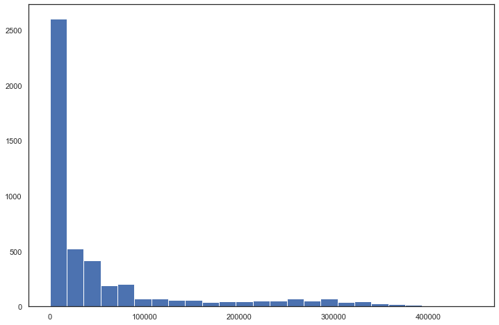

```python
plt.figure(figsize=(12,8))
plt.hist(tmdb_df['id'], bins=25)
```

```python
tmdb_df[tmdb_df['id']==5]
```

|  | id | title | budget | cast | crew | genres | keywords | original_language | original_title | overview | popularity | production_companies | production_countries | release_date | revenue | runtime | spoken_languages | vote_average | vote_count |
| --- | --- | --- | --- | --- | --- | --- | --- | --- | --- | --- | --- | --- | --- | --- | --- | --- | --- | --- | --- |
| 3764 | 5 | Four Rooms | 4000000 | cast_id character ... | credit_id department gend... | id name 0 80 Crime 1 35 Comedy | id name 0 612 ... | en | Four Rooms | It's Ted the Bellhop's first night on the job.... | 22.87623 | name id 0 Miramax Films 14 1 ... | iso_3166_1 name 0 ... | 1995-12-09 | 4300000 | 98.0 | iso_639_1 name 0 en English | 6.5 | 530 |

```python
tmdb_df[tmdb_df['id']==447027]
```

|  | id | title | budget | cast | crew | genres | keywords | original_language | original_title | overview | popularity | production_companies | production_countries | release_date | revenue | runtime | spoken_languages | vote_average | vote_count |
| --- | --- | --- | --- | --- | --- | --- | --- | --- | --- | --- | --- | --- | --- | --- | --- | --- | --- | --- | --- |
| 3668 | 447027 | Running Forever | 0 | Empty DataFrame Columns: [] Index: [] | Empty DataFrame Columns: [] Index: [] | id name 0 10751 Family | Empty DataFrame Columns: [] Index: [] | en | Running Forever | After being estranged since her mother's death... | 0.028756 | name id 0 New Kingdom ... | iso_3166_1 name 0 ... | 2015-10-27 | 0 | 88.0 | Empty DataFrame Columns: [] Index: [] | 0.0 | 0 |

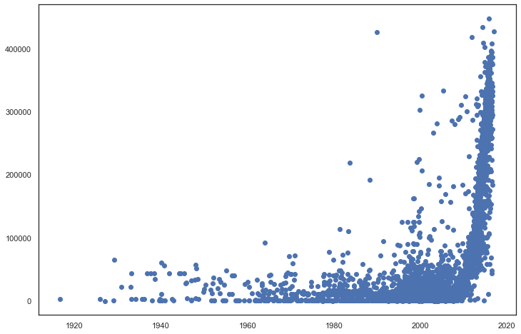

```python
plt.figure(figsize=(12,8))
plt.scatter(tmdb_df['release_date'], tmdb_df['id'])
```

ID is not strictly assigned in the time sequence of release date, but some correlation is observed

### Column 1: "Title"

```python
len(tmdb_df['title'])
```

```
4791
```

```python
tmdb_df['title'].nunique()
```

```
4788
```

Three duplicated titles are found and discussed in the data preprocessing section

```python
tmdb_df['title'].str.len().describe()
```

```
count    4791.000000
mean       15.337925
std         8.421787
min         1.000000
25%        10.000000
50%        14.000000
75%        19.000000
max        86.000000
Name: title, dtype: float64
```

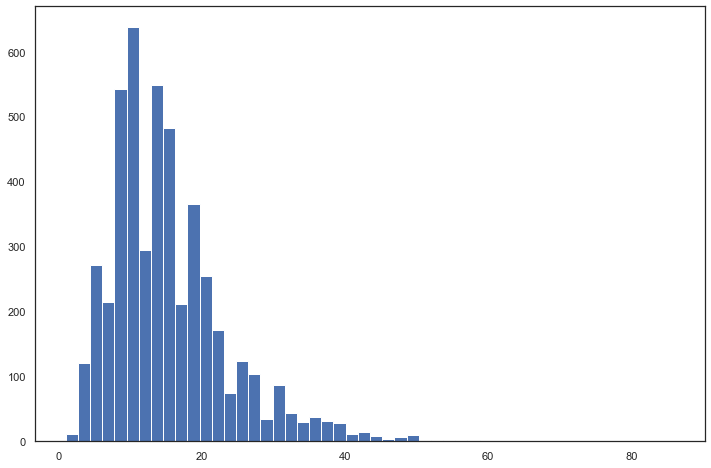

```python
plt.figure(figsize=(12,8))
plt.hist(tmdb_df['title'].str.len(), bins=50)
```

```python
title_tokens = list(tmdb_df['title'].apply(word_tokenize))
title_tokens = list(chain.from_iterable(title_tokens))

counter = Counter(title_tokens)
```

```python
title_tokens_freq = pd.DataFrame(counter.items(), columns=['word', 'count'])
title_tokens_freq['frequency'] = title_tokens_freq['count']/len(tmdb_df['title'])

title_tokens_freq
```

|  | word | count | frequency |
| --- | --- | --- | --- |
| 0 | Avatar | 1 | 0.000209 |
| 1 | Pirates | 7 | 0.001461 |
| 2 | of | 468 | 0.097683 |
| 3 | the | 423 | 0.088291 |
| 4 | Caribbean | 4 | 0.000835 |
| ... | ... | ... | ... |
| 4778 | Mariachi | 1 | 0.000209 |
| 4779 | Newlyweds | 1 | 0.000209 |
| 4780 | Signed | 1 | 0.000209 |
| 4781 | Sealed | 1 | 0.000209 |
| 4782 | Delivered | 1 | 0.000209 |

4783 rows × 3 columns

```python
title_tokens_freq = title_tokens_freq.sort_values(by=['frequency'], ascending=False)
title_tokens_freq.reset_index(drop=True, inplace=True)
```

```python
print(title_tokens_freq.head(100).to_string())
```

```
         word  count  frequency
0         The   1099   0.229388
1          of    468   0.097683
2         the    423   0.088291
3           :    348   0.072636
4          's    177   0.036944
5         and    137   0.028595
6           2    103   0.021499
7           A     99   0.020664
8          to     98   0.020455
9          in     92   0.019203
10          a     82   0.017115
11          ,     71   0.014819
12        Man     70   0.014611
13          &     61   0.012732
```

[output cut: 86 more lines]

### Column 2: "Budget"

```python
tmdb_df['budget'].describe()
```

```
count    4.791000e+03
mean     2.911364e+07
std      4.074974e+07
min      0.000000e+00
25%      8.034740e+05
50%      1.500000e+07
75%      4.000000e+07
max      3.800000e+08
Name: budget, dtype: float64
```

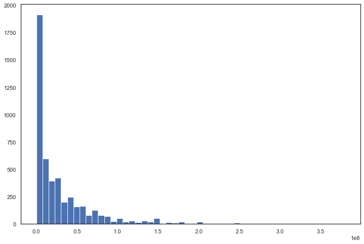

```python
plt.figure(figsize=(12,8))
plt.hist(tmdb_df['budget'], bins=50)
```

```python
budget_zero = tmdb_df[tmdb_df['budget']==0]
len(budget_zero)
```

```
1031
```

Significant number of movies have zero budge record, which is unlikely the actual case

```python
budget_zero.head()
```

|  | id | title | budget | cast | crew | genres | keywords | original_language | original_title | overview | popularity | production_companies | production_countries | release_date | revenue | runtime | spoken_languages | vote_average | vote_count |
| --- | --- | --- | --- | --- | --- | --- | --- | --- | --- | --- | --- | --- | --- | --- | --- | --- | --- | --- | --- |
| 265 | 10588 | The Cat in the Hat | 0 | cast_id charact... | credit_id department gend... | id name 0 35 Comedy 1 14 ... | id name 0 977... | en | The Cat in the Hat | Conrad and Sally Walden are home alone with th... | 18.251129 | name id 0 Imagine Entert... | iso_3166_1 name 0 ... | 2003-11-21 | 0 | 82.0 | iso_639_1 name 0 en English | 4.9 | 366 |
| 321 | 77953 | The Campaign | 0 | cast_id character ... | credit_id department gend... | id name 0 35 Comedy | id name 0 6078 ... | en | The Campaign | Two rival politicians compete to win an electi... | 16.460356 | name id 0 E... | iso_3166_1 name 0 ... | 2012-08-09 | 104907746 | 85.0 | iso_639_1 name 0 en English | 5.6 | 578 |
| 359 | 258509 | Alvin and the Chipmunks: The Road Chip | 0 | cast_id character ... | credit_id departmen... | id name 0 12 Adventure 1 ... | id name 0 10986 ... | en | Alvin and the Chipmunks: The Road Chip | Through a series of misunderstandings, Alvin, ... | 27.867368 | name id 0 Regen... | iso_3166_1 name 0 ... | 2015-12-17 | 233755553 | 92.0 | iso_639_1 name 0 en English | 5.8 | 428 |
| 406 | 51052 | Arthur Christmas | 0 | cast_id character ... | credit_id departmen... | id name 0 18 Drama 1 ... | id name 0 65 ... | en | Arthur Christmas | Each Christmas, Santa and his vast army of hig... | 19.836830 | name id 0 Colu... | iso_3166_1 name 0 ... | 2011-02-22 | 0 | 97.0 | iso_639_1 name 0 en English | 6.7 | 333 |
| 409 | 16858 | All That Jazz | 0 | cast_id charac... | credit_id departmen... | id name 0 18 Drama 1 10402 Music | id name 0 837... | en | All That Jazz | Bob Fosse's semi-autobiographical film celebra... | 5.159407 | name id... | iso_3166_1 name 0 ... | 1979-12-20 | 37823676 | 123.0 | iso_639_1 name 0 en English | 7.3 | 85 |

```python
len(budget_zero[budget_zero['revenue']!=0]), len(budget_zero[budget_zero['revenue']!=0])/len(budget_zero)
```

```
(147, 0.1425800193986421)
```

More than 14.26% of the zero-budget moives actually have a non-zero revenue record

```python
cat_in_hat = tmdb_df.iloc[265]
```

```python
cat_in_hat['overview']
```

```
"Conrad and Sally Walden are home alone with their pet fish. It is raining outside, and there is nothing to do. Until The Cat in the Hat walks in the front door. He introduces them to their imagination, and at first it's all fun and games, until things get out of hand, and The Cat must go, go, go, b…
```

```python
cat_in_hat['cast']
```

|  | cast_id | character | credit_id | gender | id | name | order |
| --- | --- | --- | --- | --- | --- | --- | --- |
| 0 | 1 | The Cat | 52fe438d9251416c75014d51 | 2 | 12073 | Mike Myers | 0 |
| 1 | 4 | Sally Walden | 52fe438d9251416c75014d5d | 1 | 501 | Dakota Fanning | 1 |
| 2 | 5 | Conrad Walden | 52fe438d9251416c75014d61 | 2 | 35654 | Spencer Breslin | 2 |
| 3 | 3 | Joan Walden | 52fe438d9251416c75014d59 | 1 | 11164 | Kelly Preston | 3 |
| 4 | 2 | Larry Quinn | 52fe438d9251416c75014d55 | 2 | 7447 | Alec Baldwin | 4 |
| 5 | 6 | Mrs. Kwan | 52fe438d9251416c75014d65 | 1 | 59401 | Amy Hill | 5 |
| 6 | 20 | Mr. Humberfloob / Voice of the Fish | 52fe438d9251416c75014db7 | 2 | 52601 | Sean Hayes | 6 |
| 7 | 21 | Thing One | 52fe438d9251416c75014dbb | 1 | 135532 | Danielle Ryan Chuchran | 7 |
| 8 | 22 | Thing One | 52fe438d9251416c75014dbf | 0 | 1056728 | Taylor Rice | 8 |
| 9 | 23 | Thing Two | 52fe438d9251416c75014dc3 | 1 | 982705 | Brittany Oaks | 9 |
| 10 | 24 | Thing Two | 52fe438d9251416c75014dc7 | 0 | 168388 | Talia-Lynn Prairie | 10 |

```python
cat_in_hat['crew']
```

|  | credit_id | department | gender | id | job | name |
| --- | --- | --- | --- | --- | --- | --- |
| 0 | 52fe438d9251416c75014d95 | Production | 2 | 2445 | Executive Producer | Eric McLeod |
| 1 | 52fe438d9251416c75014d89 | Production | 2 | 339 | Producer | Brian Grazer |
| 2 | 52fe438d9251416c75014da7 | Sound | 2 | 3393 | Original Music Composer | David Newman |
| 3 | 52fe438d9251416c75014dad | Camera | 2 | 4185 | Director of Photography | Emmanuel Lubezki |
| 4 | 52fe438d9251416c75014d6b | Directing | 2 | 5133 | Director | Bo Welch |
| 5 | 52fe438d9251416c75014d8f | Production | 1 | 5283 | Executive Producer | Karen Kehela Sherwood |
| 6 | 52fe438d9251416c75014d9b | Production | 1 | 6185 | Executive Producer | Maureen Peyrot |
| 7 | 52fe438d9251416c75014db3 | Editing | 2 | 15005 | Editor | Don Zimmerman |
| 8 | 52fe438d9251416c75014d83 | Writing | 2 | 57405 | Screenplay | Jeff Schaffer |
| 9 | 52fe438d9251416c75014d77 | Writing | 0 | 57406 | Screenplay | Alec Berg |
| 10 | 52fe438d9251416c75014d7d | Writing | 2 | 57407 | Screenplay | David Mandel |
| 11 | 52fe438d9251416c75014d71 | Writing | 2 | 65705 | Novel | Dr. Seuss |
| 12 | 52fe438d9251416c75014da1 | Production | 0 | 65706 | Executive Producer | Gregg Taylor |
| 13 | 5526d3b6925141118a002c98 | Art | 1 | 963843 | Art Department Manager | Priscilla Elliott |
| 14 | 552c7649c3a3685a67000a79 | Art | 0 | 1451229 | Art Department Manager | Luc Desmarchelier |
| 15 | 553dda6ac3a3683e140074b7 | Camera | 0 | 1451245 | Camera Department Manager | Tyler Allison |

```python
cat_in_hat['production_companies']
```

|  | name | id |
| --- | --- | --- |
| 0 | Imagine Entertainment | 23 |
| 1 | DreamWorks SKG | 27 |
| 2 | Universal Pictures | 33 |

```python
cat_in_hat['budget'], cat_in_hat['revenue']
```

```
(0, 0)
```

Having checked the IMDb website for the record of "the Cat in the Hat", it is found that this movie actually has the estimated budget of USD 109,000,000 and the cumulative worldwide gross of USD 133,960,541. For more details to refer to the link: https://www.imdb.com/title/tt0312528/

```python
budget_non_zero = tmdb_df[tmdb_df['budget']!=0]
```

```python
budget_non_zero['budget'].describe()
```

```
count    3.760000e+03
mean     3.709666e+07
std      4.265870e+07
min      1.000000e+00
25%      8.000000e+06
50%      2.300000e+07
75%      5.000000e+07
max      3.800000e+08
Name: budget, dtype: float64
```

```python
budget_non_zero[budget_non_zero['budget']<10000].head()
```

|  | id | title | budget | cast | crew | genres | keywords | original_language | original_title | overview | popularity | production_companies | production_countries | release_date | revenue | runtime | spoken_languages | vote_average | vote_count |
| --- | --- | --- | --- | --- | --- | --- | --- | --- | --- | --- | --- | --- | --- | --- | --- | --- | --- | --- | --- |
| 1095 | 1494 | Curse of the Golden Flower | 110 | cast_id character ... | credit_id departmen... | id name 0 28 Action 1 18 Drama 2... | id name 0 351 ... | zh | 滿城盡帶黃金甲 | During China's Tang dynasty the emperor has ta... | 9.950505 | name id 0 B... | iso_3166_1 name 0 CN Chin... | 2006-12-21 | 0 | 114.0 | iso_639_1 name 0 zh 普通话 | 6.6 | 203 |
| 1562 | 16340 | Rugrats in Paris: The Movie | 30 | cast_id ... | credit_id department ... | id name 0 12 Adventure 1 ... | id name 0 90 paris 1 3338 ... | it | Rugrats in Paris: The Movie | The Rugrats are back! There's Tommy the brave ... | 4.590277 | name id 0 Paramount Pi... | iso_3166_1 name 0 ... | 2000-09-14 | 103 | 78.0 | iso_639_1 name 0 en English | 6.0 | 100 |
| 1771 | 1613 | The 51st State | 28 | cast_id character ... | credit_id departmen... | id name 0 53 Thriller 1 28 Actio... | id name 0 852 chemical 1 2... | en | The 51st State | Elmo McElroy is a streetwise American master c... | 9.670031 | ... | iso_3166_1 name 0 CA ... | 2001-12-07 | 14 | 93.0 | iso_639_1 name 0 en English | 5.9 | 173 |
| 1912 | 10397 | Angela's Ashes | 25 | cast_id character ... | credit_id department gende... | id name 0 18 Drama | id name 0 1625 ... | en | Angela's Ashes | Based on the best selling autobiography by Iri... | 4.887940 | name id 0 Paramount Picture... | iso_3166_1 name 0 ... | 1999-12-25 | 13 | 145.0 | iso_639_1 name 0 en English | 7.0 | 59 |
| 2617 | 72359 | Peeples | 15 | cast_id character cr... | credit_id departmen... | id name 0 35 Comedy | id name 0 179431 dur... | en | Peeples | The story follows what happens when a child ps... | 5.112809 | name id 0 34th Street Fi... | iso_3166_1 name 0 ... | 2013-05-09 | 0 | 95.0 | iso_639_1 name 0 en English | 5.6 | 26 |

```python
budget_non_zero[budget_non_zero['budget']<10000].iloc[0][['id', 'title', 'budget',
                                                          'original_language', 'original_title',
                                                          'popularity', 'release_date', 'revenue',
                                                          'runtime', 'vote_average', 'vote_count']]
```

```
id                                         1494
title                Curse of the Golden Flower
budget                                      110
original_language                            zh
original_title                          滿城盡帶黃金甲
popularity                               9.9505
release_date                2006-12-21 00:00:00
revenue                                       0
runtime                                     114
vote_average                                6.6
vote_count                                  203
Name: 1095, dtype: object
```

Having checked the IMDb website for the record of "Curse of the Golden Flower", it is found that this movie actually has the estimated budget of USD 45,000,000 and the cumulative worldwide gross of USD 78,568,977. For more details to refer to the link: https://www.imdb.com/title/tt0473444/

```python
tmdb_df.drop(['budget'], axis=1, inplace=True)
tmdb_df.head()
```

|  | id | title | cast | crew | genres | keywords | original_language | original_title | overview | popularity | production_companies | production_countries | release_date | revenue | runtime | spoken_languages | vote_average | vote_count |
| --- | --- | --- | --- | --- | --- | --- | --- | --- | --- | --- | --- | --- | --- | --- | --- | --- | --- | --- |
| 0 | 19995 | Avatar | cast_id character ... | credit_id department gen... | id name 0 28 Actio... | id name 0 1463 cult... | en | Avatar | In the 22nd century, a paraplegic Marine is di... | 150.437577 | name id... | iso_3166_1 name 0 ... | 2009-12-10 | 2787965087 | 162.0 | iso_639_1 name 0 en English 1 ... | 7.2 | 11800 |
| 1 | 285 | Pirates of the Caribbean: At World's End | cast_id character ... | credit_id departmen... | id name 0 12 Adventure 1 14 Fan... | id name 0 ... | en | Pirates of the Caribbean: At World's End | Captain Barbossa, long believed to be dead, ha... | 139.082615 | name id 0 Walt D... | iso_3166_1 name 0 ... | 2007-05-19 | 961000000 | 169.0 | iso_639_1 name 0 en English | 6.9 | 4500 |
| 2 | 206647 | Spectre | cast_id character ... | credit_id department ... | id name 0 28 Action 1 12 Adven... | id name 0 470 ... | en | Spectre | A cryptic message from Bond’s past sends him o... | 107.376788 | name id 0 Columbia Pictur... | iso_3166_1 name 0 ... | 2015-10-26 | 880674609 | 148.0 | iso_639_1 name 0 fr Français 1 ... | 6.3 | 4466 |
| 3 | 49026 | The Dark Knight Rises | cast_id character ... | credit_id departme... | id name 0 28 Action 1 80 Crim... | id name 0 849 ... | en | The Dark Knight Rises | Following the death of District Attorney Harve... | 112.312950 | name id 0 Legendary Pictu... | iso_3166_1 name 0 ... | 2012-07-16 | 1084939099 | 165.0 | iso_639_1 name 0 en English | 7.6 | 9106 |
| 4 | 49529 | John Carter | cast_id character ... | credit_id department gen... | id name 0 28 Actio... | id name 0 818 ... | en | John Carter | John Carter is a war-weary, former military ca... | 43.926995 | name id 0 Walt Disney Pic... | iso_3166_1 name 0 ... | 2012-03-07 | 284139100 | 132.0 | iso_639_1 name 0 en English | 6.1 | 2124 |

Budget of the movies is too flawful to be selected for consequent data mining process

### Column 3: "Cast"

```python
avatar_cast = tmdb_df.loc[0, 'cast'].copy()
avatar_cast
```

|  | cast_id | character | credit_id | gender | id | name | order |
| --- | --- | --- | --- | --- | --- | --- | --- |
| 0 | 242 | Jake Sully | 5602a8a7c3a3685532001c9a | 2 | 65731 | Sam Worthington | 0 |
| 1 | 3 | Neytiri | 52fe48009251416c750ac9cb | 1 | 8691 | Zoe Saldana | 1 |
| 2 | 25 | Dr. Grace Augustine | 52fe48009251416c750aca39 | 1 | 10205 | Sigourney Weaver | 2 |
| 3 | 4 | Col. Quaritch | 52fe48009251416c750ac9cf | 2 | 32747 | Stephen Lang | 3 |
| 4 | 5 | Trudy Chacon | 52fe48009251416c750ac9d3 | 1 | 17647 | Michelle Rodriguez | 4 |
| ... | ... | ... | ... | ... | ... | ... | ... |
| 78 | 98 | Female Marine (uncredited) | 52fe48019251416c750acb5f | 0 | 1207291 | Jodie Taylor | 78 |
| 79 | 99 | Ikran Clan Leader (uncredited) | 52fe48019251416c750acb63 | 1 | 1186027 | Alicia Vela-Bailey | 79 |
| 80 | 100 | Geologist (uncredited) | 52fe48019251416c750acb67 | 0 | 1207292 | Richard Whiteside | 80 |
| 81 | 101 | Na'vi (uncredited) | 52fe48019251416c750acb6b | 0 | 103259 | Nikie Zambo | 81 |
| 82 | 102 | Ambient Room Tech / Troupe | 52fe48019251416c750acb6f | 1 | 42286 | Julene Renee | 82 |

83 rows × 7 columns

```python
def uncredited_cost(character):
    return '(uncredited)' in character
```

```python
def remove_uncredited(character):
    return character.replace(' (uncredited)','')
```

```python
avatar_cast['uncredited'] = avatar_cast['character'].apply(uncredited_cost)
avatar_cast['character'] = avatar_cast['character'].apply(remove_uncredited)

avatar_cast
```

|  | cast_id | character | credit_id | gender | id | name | order | uncredited |
| --- | --- | --- | --- | --- | --- | --- | --- | --- |
| 0 | 242 | Jake Sully | 5602a8a7c3a3685532001c9a | 2 | 65731 | Sam Worthington | 0 | False |
| 1 | 3 | Neytiri | 52fe48009251416c750ac9cb | 1 | 8691 | Zoe Saldana | 1 | False |
| 2 | 25 | Dr. Grace Augustine | 52fe48009251416c750aca39 | 1 | 10205 | Sigourney Weaver | 2 | False |
| 3 | 4 | Col. Quaritch | 52fe48009251416c750ac9cf | 2 | 32747 | Stephen Lang | 3 | False |
| 4 | 5 | Trudy Chacon | 52fe48009251416c750ac9d3 | 1 | 17647 | Michelle Rodriguez | 4 | False |
| ... | ... | ... | ... | ... | ... | ... | ... | ... |
| 78 | 98 | Female Marine | 52fe48019251416c750acb5f | 0 | 1207291 | Jodie Taylor | 78 | True |
| 79 | 99 | Ikran Clan Leader | 52fe48019251416c750acb63 | 1 | 1186027 | Alicia Vela-Bailey | 79 | True |
| 80 | 100 | Geologist | 52fe48019251416c750acb67 | 0 | 1207292 | Richard Whiteside | 80 | True |
| 81 | 101 | Na'vi | 52fe48019251416c750acb6b | 0 | 103259 | Nikie Zambo | 81 | True |
| 82 | 102 | Ambient Room Tech / Troupe | 52fe48019251416c750acb6f | 1 | 42286 | Julene Renee | 82 | False |

83 rows × 8 columns

```python
avatar_cast['uncredited'].value_counts()
```

```
False    62
True     21
Name: uncredited, dtype: int64
```

```python
def rename_gender(gender):
    if gender == 1:
        return "F"
    elif gender == 2:
        return "M"
    else:
        return "N/A"
```

```python
avatar_cast['gender'] = avatar_cast['gender'].apply(rename_gender)
avatar_cast
```

|  | cast_id | character | credit_id | gender | id | name | order | uncredited |
| --- | --- | --- | --- | --- | --- | --- | --- | --- |
| 0 | 242 | Jake Sully | 5602a8a7c3a3685532001c9a | M | 65731 | Sam Worthington | 0 | False |
| 1 | 3 | Neytiri | 52fe48009251416c750ac9cb | F | 8691 | Zoe Saldana | 1 | False |
| 2 | 25 | Dr. Grace Augustine | 52fe48009251416c750aca39 | F | 10205 | Sigourney Weaver | 2 | False |
| 3 | 4 | Col. Quaritch | 52fe48009251416c750ac9cf | M | 32747 | Stephen Lang | 3 | False |
| 4 | 5 | Trudy Chacon | 52fe48009251416c750ac9d3 | F | 17647 | Michelle Rodriguez | 4 | False |
| ... | ... | ... | ... | ... | ... | ... | ... | ... |
| 78 | 98 | Female Marine | 52fe48019251416c750acb5f | N/A | 1207291 | Jodie Taylor | 78 | True |
| 79 | 99 | Ikran Clan Leader | 52fe48019251416c750acb63 | F | 1186027 | Alicia Vela-Bailey | 79 | True |
| 80 | 100 | Geologist | 52fe48019251416c750acb67 | N/A | 1207292 | Richard Whiteside | 80 | True |
| 81 | 101 | Na'vi | 52fe48019251416c750acb6b | N/A | 103259 | Nikie Zambo | 81 | True |
| 82 | 102 | Ambient Room Tech / Troupe | 52fe48019251416c750acb6f | F | 42286 | Julene Renee | 82 | False |

83 rows × 8 columns

```python
avatar_cast['gender'].value_counts()
```

```
N/A    51
M      20
F      12
Name: gender, dtype: int64
```

```python
n_cast = tmdb_df['cast'].apply(len)
n_cast
```

```
0        83
1        34
2        83
3       158
4        27
       ...
4786      7
4787      5
4788      7
4789      5
4790      8
Name: cast, Length: 4791, dtype: int64
```

```python
n_cast.describe()
```

```
count    4791.000000
mean       22.166354
std        19.586298
min         0.000000
25%        11.000000
50%        17.000000
75%        25.000000
max       224.000000
Name: cast, dtype: float64
```

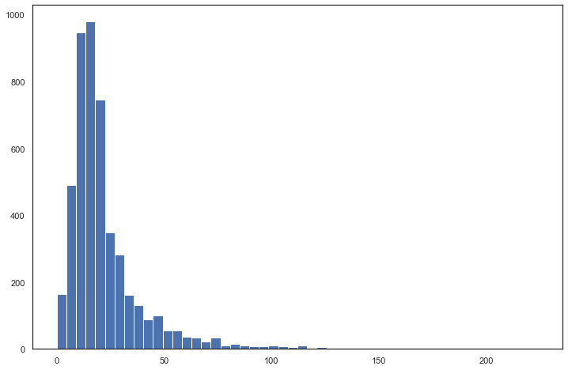

```python
plt.figure(figsize=(12,8))
plt.hist(n_cast, bins=50)
```

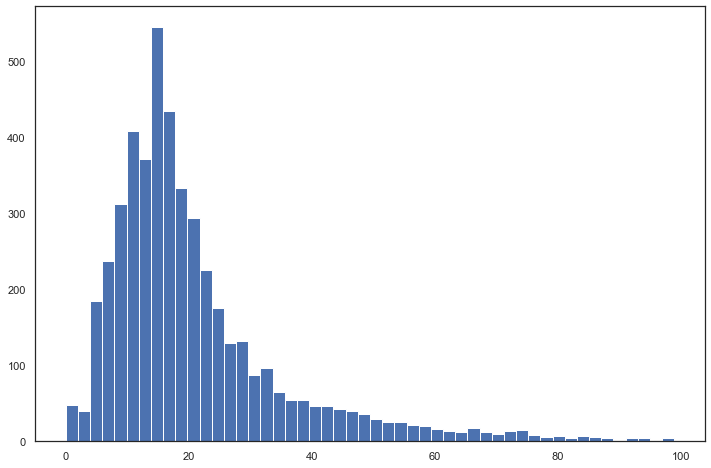

```python
plt.figure(figsize=(12,8))
plt.hist(n_cast[n_cast<100], bins=50)
```

```python
np.sum(n_cast<10), np.sum(n_cast<5), np.sum(n_cast<3)
```

```
(821, 163, 58)
```

```python
tmdb_df['cast_num'] = n_cast
```

```python
def main_cast(cast, n_main=3):
    cast_pattern = np.array([np.nan, None, np.nan])
    if cast.empty:
        return np.tile(cast_pattern, n_main)
    else:
        n_cast = len(cast)
        cast_extract = cast.loc[:min(n_main-1, n_cast), ['id','name', 'gender']].values.flatten()
        return np.append(cast_extract, np.tile(cast_pattern, max(0, n_main-n_cast)))
```

```python
main_cast(avatar_cast)
```

```
array([65731, 'Sam Worthington', 'M', 8691, 'Zoe Saldana', 'F', 10205,
       'Sigourney Weaver', 'F'], dtype=object)
```

```python
tmdb_df[n_cast==1].head()
```

|  | id | title | cast | crew | genres | keywords | original_language | original_title | overview | popularity | production_companies | production_countries | release_date | revenue | runtime | spoken_languages | vote_average | vote_count | cast_num |
| --- | --- | --- | --- | --- | --- | --- | --- | --- | --- | --- | --- | --- | --- | --- | --- | --- | --- | --- | --- |
| 3222 | 152747 | All Is Lost | cast_id character credit_id... | credit_id departmen... | id name 0 28 Action 1 12 Adven... | id name 0 3342 ... | en | All Is Lost | Deep into a solo voyage in the Indian Ocean, a... | 28.540614 | name id 0 Sudden S... | iso_3166_1 name 0 ... | 2013-10-18 | 6108720 | 106.0 | iso_639_1 name 0 en English | 6.6 | 671 | 1 |
| 3766 | 19153 | The Real Cancun | cast_id character credit_id... | credit_id department gender... | id name 0 99 Documentary | id name 0 10183 independe... | en | The Real Cancun | Sixteen American college students drink, flirt... | 0.456485 | Empty DataFrame Columns: [] Index: [] | iso_3166_1 name 0 ... | 2003-04-23 | 0 | 96.0 | iso_639_1 name 0 en English | 3.3 | 8 | 1 |
| 3895 | 20337 | Martin Lawrence Live: Runteldat | cast_id character credit_id... | credit_id department gende... | id name 0 35 Comedy | id name 0 1850 daily life 1 ... | en | Martin Lawrence Live: Runteldat | The controversial bad-boy of comedy delivers a... | 0.295226 | Empty DataFrame Columns: [] Index: [] | iso_3166_1 name 0 ... | 2002-08-01 | 19184015 | 113.0 | iso_639_1 name 0 en English | 5.0 | 1 | 1 |
| 4323 | 202604 | The Vatican Exorcisms | cast_id character credit_id... | credit_id department gender... | id name 0 27 Horror 1 ... | id name 0 2626 exorcism | en | The Vatican Exorcisms | Documentary following US film-maker Joe Marino... | 0.447166 | Empty DataFrame Columns: [] Index: [] | Empty DataFrame Columns: [] Index: [] | 2013-05-29 | 0 | 0.0 | iso_639_1 name 0 it Italiano 1 ... | 4.4 | 11 | 1 |
| 4460 | 40862 | Iraq for Sale: The War Profiteers | cast_id character credit_id... | credit_id department gender... | id name 0 99 Documentary | Empty DataFrame Columns: [] Index: [] | en | Iraq for Sale: The War Profiteers | Documentary portraying the actions of U.S. cor... | 1.517771 | Empty DataFrame Columns: [] Index: [] | Empty DataFrame Columns: [] Index: [] | 2006-01-01 | 0 | 75.0 | iso_639_1 name 0 en English | 8.0 | 6 | 1 |

```python
all_is_lost_cast = tmdb_df.iloc[3222]['cast']
all_is_lost_cast
```

|  | cast_id | character | credit_id | gender | id | name | order |
| --- | --- | --- | --- | --- | --- | --- | --- |
| 0 | 7 | Our Man | 52fe4b299251416c910d1f2b | 2 | 4135 | Robert Redford | 0 |

```python
main_cast(all_is_lost_cast)
```

```
array([4135, 'Robert Redford', 2, nan, None, nan, nan, None, nan],
      dtype=object)
```

```python
tmdb_df[n_cast==0].head()
```

|  | id | title | cast | crew | genres | keywords | original_language | original_title | overview | popularity | production_companies | production_countries | release_date | revenue | runtime | spoken_languages | vote_average | vote_count | cast_num |
| --- | --- | --- | --- | --- | --- | --- | --- | --- | --- | --- | --- | --- | --- | --- | --- | --- | --- | --- | --- |
| 2601 | 17644 | Barney's Great Adventure | Empty DataFrame Columns: [] Index: [] | credit_id department gender... | id name 0 10751 Family | Empty DataFrame Columns: [] Index: [] | en | Barney's Great Adventure | Mom and dad dump son Cody, daughter Abby, her ... | 0.722911 | name id 0 Pol... | iso_3166_1 name 0 ... | 1998-01-01 | 0 | 76.0 | iso_639_1 name 0 en English | 2.9 | 8 | 0 |
| 3668 | 447027 | Running Forever | Empty DataFrame Columns: [] Index: [] | Empty DataFrame Columns: [] Index: [] | id name 0 10751 Family | Empty DataFrame Columns: [] Index: [] | en | Running Forever | After being estranged since her mother's death... | 0.028756 | name id 0 New Kingdom ... | iso_3166_1 name 0 ... | 2015-10-27 | 0 | 88.0 | Empty DataFrame Columns: [] Index: [] | 0.0 | 0 | 0 |
| 3990 | 346081 | Sardaarji | Empty DataFrame Columns: [] Index: [] | credit_id department gender... | Empty DataFrame Columns: [] Index: [] | Empty DataFrame Columns: [] Index: [] | en | Sardaarji | A ghost hunter uses bottles to capture trouble... | 0.296981 | Empty DataFrame Columns: [] Index: [] | iso_3166_1 name 0 IN India | 2015-06-26 | 0 | 0.0 | Empty DataFrame Columns: [] Index: [] | 9.5 | 2 | 0 |
| 4007 | 126509 | 2016: Obama's America | Empty DataFrame Columns: [] Index: [] | credit_id department gende... | id name 0 99 Documentary | Empty DataFrame Columns: [] Index: [] | en | 2016: Obama's America | 2016: Obama's America takes audiences on a gri... | 0.973582 | Empty DataFrame Columns: [] Index: [] | iso_3166_1 name 0 ... | 2012-07-13 | 33400000 | 87.0 | iso_639_1 name 0 en English | 4.6 | 19 | 0 |
| 4066 | 371085 | Sharkskin | Empty DataFrame Columns: [] Index: [] | Empty DataFrame Columns: [] Index: [] | Empty DataFrame Columns: [] Index: [] | Empty DataFrame Columns: [] Index: [] | en | Sharkskin | The Post War II story of Manhattan born Mike E... | 0.027801 | Empty DataFrame Columns: [] Index: [] | Empty DataFrame Columns: [] Index: [] | 2015-01-01 | 0 | 0.0 | Empty DataFrame Columns: [] Index: [] | 0.0 | 0 | 0 |

```python
obama_cast = tmdb_df.iloc[4007]['cast']
obama_cast.empty
```

```
True
```

```python
main_cast(obama_cast)
```

```
array([nan, None, nan, nan, None, nan, nan, None, nan], dtype=object)
```

```python
tmdb_df_main_cast = tmdb_df['cast'].apply(main_cast)
```

```python
main_cast_columns = [['cast_'+str(i)+'_id', 'cast_'+str(i)+'_name', 'cast_'+str(i)+'_gender'] for i in range(3)]
main_cast_columns = list(chain.from_iterable(main_cast_columns))

main_cast_df = pd.DataFrame(np.array(tmdb_df_main_cast.values.tolist()), columns=main_cast_columns)
main_cast_df
```

|  | cast_0_id | cast_0_name | cast_0_gender | cast_1_id | cast_1_name | cast_1_gender | cast_2_id | cast_2_name | cast_2_gender |
| --- | --- | --- | --- | --- | --- | --- | --- | --- | --- |
| 0 | 65731 | Sam Worthington | 2 | 8691 | Zoe Saldana | 1 | 10205 | Sigourney Weaver | 1 |
| 1 | 85 | Johnny Depp | 2 | 114 | Orlando Bloom | 2 | 116 | Keira Knightley | 1 |
| 2 | 8784 | Daniel Craig | 2 | 27319 | Christoph Waltz | 2 | 121529 | Léa Seydoux | 1 |
| 3 | 3894 | Christian Bale | 2 | 3895 | Michael Caine | 2 | 64 | Gary Oldman | 2 |
| 4 | 60900 | Taylor Kitsch | 2 | 21044 | Lynn Collins | 1 | 2206 | Samantha Morton | 1 |
| ... | ... | ... | ... | ... | ... | ... | ... | ... | ... |
| 4786 | 20498 | Carlos Gallardo | 2 | 57470 | Jaime de Hoyos | 0 | 57471 | Peter Marquardt | 2 |
| 4787 | 12833 | Edward Burns | 2 | 58356 | Kerry Bishé | 1 | 17188 | Marsha Dietlein | 1 |
| 4788 | 11867 | Eric Mabius | 2 | 34915 | Kristin Booth | 1 | 58393 | Crystal Lowe | 1 |
| 4789 | 82093 | Daniel Henney | 2 | 210050 | Eliza Coupe | 1 | 2053 | Bill Paxton | 2 |
| 4790 | 69597 | Drew Barrymore | 1 | 85563 | Brian Herzlinger | 2 | 3034 | Corey Feldman | 2 |

4791 rows × 9 columns

```python
tmdb_df = tmdb_df.join(main_cast_df)
tmdb_df.head()
```

|  | id | title | cast | crew | genres | keywords | original_language | original_title | overview | popularity | ... | cast_num | cast_0_id | cast_0_name | cast_0_gender | cast_1_id | cast_1_name | cast_1_gender | cast_2_id | cast_2_name | cast_2_gender |
| --- | --- | --- | --- | --- | --- | --- | --- | --- | --- | --- | --- | --- | --- | --- | --- | --- | --- | --- | --- | --- | --- |
| 0 | 19995 | Avatar | cast_id character ... | credit_id department gen... | id name 0 28 Actio... | id name 0 1463 cult... | en | Avatar | In the 22nd century, a paraplegic Marine is di... | 150.437577 | ... | 83 | 65731 | Sam Worthington | 2 | 8691 | Zoe Saldana | 1 | 10205 | Sigourney Weaver | 1 |
| 1 | 285 | Pirates of the Caribbean: At World's End | cast_id character ... | credit_id departmen... | id name 0 12 Adventure 1 14 Fan... | id name 0 ... | en | Pirates of the Caribbean: At World's End | Captain Barbossa, long believed to be dead, ha... | 139.082615 | ... | 34 | 85 | Johnny Depp | 2 | 114 | Orlando Bloom | 2 | 116 | Keira Knightley | 1 |
| 2 | 206647 | Spectre | cast_id character ... | credit_id department ... | id name 0 28 Action 1 12 Adven... | id name 0 470 ... | en | Spectre | A cryptic message from Bond’s past sends him o... | 107.376788 | ... | 83 | 8784 | Daniel Craig | 2 | 27319 | Christoph Waltz | 2 | 121529 | Léa Seydoux | 1 |
| 3 | 49026 | The Dark Knight Rises | cast_id character ... | credit_id departme... | id name 0 28 Action 1 80 Crim... | id name 0 849 ... | en | The Dark Knight Rises | Following the death of District Attorney Harve... | 112.312950 | ... | 158 | 3894 | Christian Bale | 2 | 3895 | Michael Caine | 2 | 64 | Gary Oldman | 2 |
| 4 | 49529 | John Carter | cast_id character ... | credit_id department gen... | id name 0 28 Actio... | id name 0 818 ... | en | John Carter | John Carter is a war-weary, former military ca... | 43.926995 | ... | 27 | 60900 | Taylor Kitsch | 2 | 21044 | Lynn Collins | 1 | 2206 | Samantha Morton | 1 |

5 rows × 28 columns

```python
def cast_gender(cast):
    gender_counts = np.full(3, 0)
    if not cast.empty:
        groupby_counts = cast['gender'].value_counts()

        for i in range(3):
            if i in groupby_counts.index:
                gender_counts[i]= groupby_counts[i]

    return gender_counts
```

```python
cast_gender(all_is_lost_cast)
```

```
array([0, 0, 1])
```

```python
cast_gender(obama_cast)
```

```
array([0, 0, 0])
```

```python
tmdb_df_cast_gender = tmdb_df['cast'].apply(cast_gender)
```

```python
cast_gender_columns = ['cast_gender_na', 'cast_gender_f', 'cast_gender_m']

cast_gender_df = pd.DataFrame(np.array(tmdb_df_cast_gender.values.tolist()), columns=cast_gender_columns)
cast_gender_df
```

|  | cast_gender_na | cast_gender_f | cast_gender_m |
| --- | --- | --- | --- |
| 0 | 51 | 12 | 20 |
| 1 | 4 | 5 | 25 |
| 2 | 15 | 13 | 55 |
| 3 | 74 | 11 | 73 |
| 4 | 2 | 6 | 19 |
| ... | ... | ... | ... |
| 4786 | 4 | 0 | 3 |
| 4787 | 1 | 3 | 1 |
| 4788 | 1 | 4 | 2 |
| 4789 | 1 | 1 | 3 |
| 4790 | 1 | 1 | 6 |

4791 rows × 3 columns

```python
tmdb_df = tmdb_df.join(cast_gender_df)
tmdb_df.head()
```

|  | id | title | cast | crew | genres | keywords | original_language | original_title | overview | popularity | ... | cast_0_gender | cast_1_id | cast_1_name | cast_1_gender | cast_2_id | cast_2_name | cast_2_gender | cast_gender_na | cast_gender_f | cast_gender_m |
| --- | --- | --- | --- | --- | --- | --- | --- | --- | --- | --- | --- | --- | --- | --- | --- | --- | --- | --- | --- | --- | --- |
| 0 | 19995 | Avatar | cast_id character ... | credit_id department gen... | id name 0 28 Actio... | id name 0 1463 cult... | en | Avatar | In the 22nd century, a paraplegic Marine is di... | 150.437577 | ... | 2 | 8691 | Zoe Saldana | 1 | 10205 | Sigourney Weaver | 1 | 51 | 12 | 20 |
| 1 | 285 | Pirates of the Caribbean: At World's End | cast_id character ... | credit_id departmen... | id name 0 12 Adventure 1 14 Fan... | id name 0 ... | en | Pirates of the Caribbean: At World's End | Captain Barbossa, long believed to be dead, ha... | 139.082615 | ... | 2 | 114 | Orlando Bloom | 2 | 116 | Keira Knightley | 1 | 4 | 5 | 25 |
| 2 | 206647 | Spectre | cast_id character ... | credit_id department ... | id name 0 28 Action 1 12 Adven... | id name 0 470 ... | en | Spectre | A cryptic message from Bond’s past sends him o... | 107.376788 | ... | 2 | 27319 | Christoph Waltz | 2 | 121529 | Léa Seydoux | 1 | 15 | 13 | 55 |
| 3 | 49026 | The Dark Knight Rises | cast_id character ... | credit_id departme... | id name 0 28 Action 1 80 Crim... | id name 0 849 ... | en | The Dark Knight Rises | Following the death of District Attorney Harve... | 112.312950 | ... | 2 | 3895 | Michael Caine | 2 | 64 | Gary Oldman | 2 | 74 | 11 | 73 |
| 4 | 49529 | John Carter | cast_id character ... | credit_id department gen... | id name 0 28 Actio... | id name 0 818 ... | en | John Carter | John Carter is a war-weary, former military ca... | 43.926995 | ... | 2 | 21044 | Lynn Collins | 1 | 2206 | Samantha Morton | 1 | 2 | 6 | 19 |

5 rows × 31 columns

```python
tmdb_df.drop(['cast'], axis=1, inplace=True)
```

```python
(tmdb_df['cast_gender_na']/(tmdb_df['cast_gender_f']+tmdb_df['cast_gender_m'])).describe()
```

```
count    4752.000000
mean             inf
std              NaN
min         0.000000
25%         0.111111
50%         0.285714
75%         0.656152
max              inf
dtype: float64
```

```python
np.sum(tmdb_df['cast_gender_na']>0.5*(tmdb_df['cast_gender_f']+tmdb_df['cast_gender_m']))
```

```
1508
```

```python
(tmdb_df['cast_gender_f']/tmdb_df['cast_gender_m']).describe()
```

```
count    4710.000000
mean             inf
std              NaN
min         0.000000
25%         0.266667
50%         0.500000
75%         0.800000
max              inf
dtype: float64
```

```python
tmdb_df['cast_0_gender'].value_counts()
```

```
2    3327
1    1165
0     260
Name: cast_0_gender, dtype: int64
```

```python
tmdb_df['cast_1_gender'].value_counts()
```

```
2    2592
1    1766
0     385
Name: cast_1_gender, dtype: int64
```

```python
tmdb_df['cast_2_gender'].value_counts()
```

```
2    2591
1    1665
0     477
Name: cast_2_gender, dtype: int64
```

### Column 4 - "Crew"

```python
avatar_crew = tmdb_df.loc[0, 'crew'].copy()
avatar_crew
```

|  | credit_id | department | gender | id | job | name |
| --- | --- | --- | --- | --- | --- | --- |
| 0 | 52fe48009251416c750aca23 | Editing | 0 | 1721 | Editor | Stephen E. Rivkin |
| 1 | 539c47ecc3a36810e3001f87 | Art | 2 | 496 | Production Design | Rick Carter |
| 2 | 54491c89c3a3680fb4001cf7 | Sound | 0 | 900 | Sound Designer | Christopher Boyes |
| 3 | 54491cb70e0a267480001bd0 | Sound | 0 | 900 | Supervising Sound Editor | Christopher Boyes |
| 4 | 539c4a4cc3a36810c9002101 | Production | 1 | 1262 | Casting | Mali Finn |
| ... | ... | ... | ... | ... | ... | ... |
| 148 | 5592b2c3c3a36869e800003c | Crew | 0 | 1483231 | CG Supervisor | Philippe Rebours |
| 149 | 5592b317c3a36877470012af | Crew | 0 | 1483232 | CG Supervisor | Michael Takarangi |
| 150 | 5592b345c3a36877470012bb | Crew | 0 | 1483233 | CG Supervisor | David Weitzberg |
| 151 | 5592b37cc3a368775100113b | Crew | 0 | 1483234 | CG Supervisor | Ben White |
| 152 | 573c8e2f9251413f5d000094 | Crew | 1 | 1621932 | Stunts | Min Windle |

153 rows × 6 columns

```python
avatar_crew['department'].value_counts()
```

```
Crew                 38
Art                  32
Visual Effects       26
Costume & Make-Up    15
Sound                13
Production            9
Editing               8
Camera                6
Lighting              3
Writing               2
Directing             1
Name: department, dtype: int64
```

```python
avatar_crew[avatar_crew['department']=='Directing']
```

|  | credit_id | department | gender | id | job | name |
| --- | --- | --- | --- | --- | --- | --- |
| 6 | 52fe48009251416c750ac9c3 | Directing | 2 | 2710 | Director | James Cameron |

```python
avatar_crew['gender'].value_counts()
```

```
0    115
2     28
1     10
Name: gender, dtype: int64
```

```python
avatar_crew['job'].value_counts()
```

```
CG Supervisor                  19
Visual Effects Supervisor      16
Set Designer                   12
Art Direction                   7
Visual Effects Producer         6
Visual Effects Editor           5
Sound Effects Editor            4
Supervising Art Director        4
Costume Supervisor              4
Dialogue Editor                 3
Editor                          3
Stunts                          3
Supervising Sound Editor        3
Costume Design                  3
Makeup Artist                   3
Animation Director              3
Casting                         3
Assistant Art Director          2
Producer                        2
Steadicam Operator              2
Production Design               2
Set Costumer                    2
Stunt Coordinator               2
Foley                           2
Transportation Coordinator      2
Hairstylist                     2
Special Effects Coordinator     2
Director of Photography         2
Digital Intermediate            2
Choreographer                   1
Sound Re-Recording Mixer        1
Lighting Artist                 1
Production Supervisor           1
Set Decoration                  1
Still Photographer              1
Publicist                       1
Art Department Coordinator      1
Makeup Department Head          1
Screenplay                      1
Motion Capture Artist           1
Sound Designer                  1
Lighting Technician             1
Art Department Manager          1
Visual Effects Art Director     1
Music Editor                    1
Best Boy Electric               1
Modeling                        1
Conceptual Design               1
Dialect Coach                   1
Production Manager              1
Writer                          1
Construction Coordinator        1
Director                        1
Post Production Supervisor      1
Camera Operator                 1
Original Music Composer         1
Executive Producer              1
Name: job, dtype: int64
```

```python
avatar_crew[avatar_crew['job']=='Director']['name'].values[0]
```

```
'James Cameron'
```

```python
n_crew = tmdb_df['crew'].apply(len)
n_crew
```

```
0       153
1        32
2       155
3       217
4       132
       ...
4786     11
4787      8
4788     13
4789      2
4790      5
Name: crew, Length: 4791, dtype: int64
```

```python
n_crew.describe()
```

```
count    4791.000000
mean       27.040910
std        31.643631
min         0.000000
25%         8.000000
50%        16.000000
75%        32.000000
max       435.000000
Name: crew, dtype: float64
```

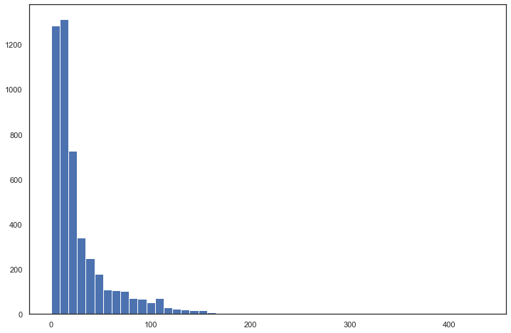

```python
plt.figure(figsize=(12,8))
plt.hist(n_crew, bins=50)
```

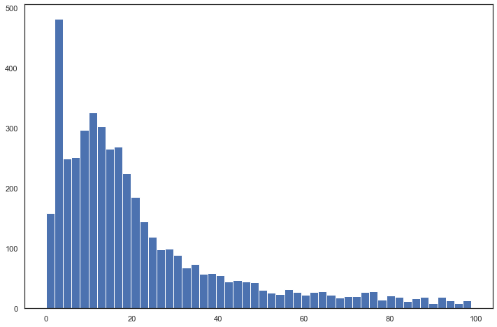

```python
plt.figure(figsize=(12,8))
plt.hist(n_crew[n_crew<100], bins=50)
```

```python
tmdb_df['crew_num'] = n_crew
```

```python
def crew_director(crew):
    if not crew.empty:
        director = crew[crew['job']=='Director']
        if not director.empty:
            return [director['id'].values[0], director['name'].values[0]]

    return [None, None]
```

```python
tmdb_df_crew_director = tmdb_df['crew'].apply(crew_director)
```

```python
crew_director_df = pd.DataFrame(np.array(tmdb_df_crew_director.values.tolist()),
                                columns=['director_id', 'director_name'])
crew_director_df
```

|  | director_id | director_name |
| --- | --- | --- |
| 0 | 2710 | James Cameron |
| 1 | 1704 | Gore Verbinski |
| 2 | 39 | Sam Mendes |
| 3 | 525 | Christopher Nolan |
| 4 | 7 | Andrew Stanton |
| ... | ... | ... |
| 4786 | 2294 | Robert Rodriguez |
| 4787 | 12833 | Edward Burns |
| 4788 | 1219158 | Scott Smith |
| 4789 | 208138 | Daniel Hsia |
| 4790 | 85563 | Brian Herzlinger |

4791 rows × 2 columns

```python
tmdb_df = tmdb_df.join(crew_director_df)
tmdb_df.head()
```

|  | id | title | crew | genres | keywords | original_language | original_title | overview | popularity | production_companies | ... | cast_1_gender | cast_2_id | cast_2_name | cast_2_gender | cast_gender_na | cast_gender_f | cast_gender_m | crew_num | director_id | director_name |
| --- | --- | --- | --- | --- | --- | --- | --- | --- | --- | --- | --- | --- | --- | --- | --- | --- | --- | --- | --- | --- | --- |
| 0 | 19995 | Avatar | credit_id department gen... | id name 0 28 Actio... | id name 0 1463 cult... | en | Avatar | In the 22nd century, a paraplegic Marine is di... | 150.437577 | name id... | ... | 1 | 10205 | Sigourney Weaver | 1 | 51 | 12 | 20 | 153 | 2710 | James Cameron |
| 1 | 285 | Pirates of the Caribbean: At World's End | credit_id departmen... | id name 0 12 Adventure 1 14 Fan... | id name 0 ... | en | Pirates of the Caribbean: At World's End | Captain Barbossa, long believed to be dead, ha... | 139.082615 | name id 0 Walt D... | ... | 2 | 116 | Keira Knightley | 1 | 4 | 5 | 25 | 32 | 1704 | Gore Verbinski |
| 2 | 206647 | Spectre | credit_id department ... | id name 0 28 Action 1 12 Adven... | id name 0 470 ... | en | Spectre | A cryptic message from Bond’s past sends him o... | 107.376788 | name id 0 Columbia Pictur... | ... | 2 | 121529 | Léa Seydoux | 1 | 15 | 13 | 55 | 155 | 39 | Sam Mendes |
| 3 | 49026 | The Dark Knight Rises | credit_id departme... | id name 0 28 Action 1 80 Crim... | id name 0 849 ... | en | The Dark Knight Rises | Following the death of District Attorney Harve... | 112.312950 | name id 0 Legendary Pictu... | ... | 2 | 64 | Gary Oldman | 2 | 74 | 11 | 73 | 217 | 525 | Christopher Nolan |
| 4 | 49529 | John Carter | credit_id department gen... | id name 0 28 Actio... | id name 0 818 ... | en | John Carter | John Carter is a war-weary, former military ca... | 43.926995 | name id 0 Walt Disney Pic... | ... | 1 | 2206 | Samantha Morton | 1 | 2 | 6 | 19 | 132 | 7 | Andrew Stanton |

5 rows × 33 columns

```python
tmdb_df.drop(['crew'], axis=1, inplace=True)
```

### Column 5 - "Genres"

```python
avatar_genres = tmdb_df.loc[0, 'genres'].copy()
avatar_genres
```

|  | id | name |
| --- | --- | --- |
| 0 | 28 | Action |
| 1 | 12 | Adventure |
| 2 | 14 | Fantasy |
| 3 | 878 | Science Fiction |

```python
n_genres = tmdb_df['genres'].apply(len)
n_genres
```

```
0       4
1       3
2       3
3       4
4       3
       ..
4786    3
4787    2
4788    4
4789    0
4790    1
Name: genres, Length: 4791, dtype: int64
```

```python
n_genres.describe()
```

```
count    4791.000000
mean        2.534126
std         1.120335
min         0.000000
25%         2.000000
50%         2.000000
75%         3.000000
max         7.000000
Name: genres, dtype: float64
```

```python
n_genres.value_counts().sort_index()
```

```
0      27
1     894
2    1488
3    1522
4     636
5     187
6      33
7       4
Name: genres, dtype: int64
```

```python
def main_genres(genres, n_main=3):
    genres_pattern = np.array([np.nan, None])
    if genres.empty:
        return np.tile(genres_pattern, n_main)
    else:
        n_genres = len(genres)
        genres_extract = genres.loc[:min(n_main-1, n_genres), ['id','name']].values.flatten()

    return np.append(genres_extract, np.tile(genres_pattern, max(0, n_main-n_genres)))
```

```python
tmdb_df_main_genres = tmdb_df['genres'].apply(main_genres)
```

```python
main_genres_columns = [['genre_'+str(i)+'_id', 'genre_'+str(i)+'_name'] for i in range(3)]
main_genres_columns = list(chain.from_iterable(main_genres_columns))

main_genres_df = pd.DataFrame(np.array(tmdb_df_main_genres.values.tolist()), columns=main_genres_columns)
main_genres_df
```

|  | genre_0_id | genre_0_name | genre_1_id | genre_1_name | genre_2_id | genre_2_name |
| --- | --- | --- | --- | --- | --- | --- |
| 0 | 28 | Action | 12 | Adventure | 14 | Fantasy |
| 1 | 12 | Adventure | 14 | Fantasy | 28 | Action |
| 2 | 28 | Action | 12 | Adventure | 80 | Crime |
| 3 | 28 | Action | 80 | Crime | 18 | Drama |
| 4 | 28 | Action | 12 | Adventure | 878 | Science Fiction |
| ... | ... | ... | ... | ... | ... | ... |
| 4786 | 28 | Action | 80 | Crime | 53 | Thriller |
| 4787 | 35 | Comedy | 10749 | Romance | NaN | None |
| 4788 | 35 | Comedy | 18 | Drama | 10749 | Romance |
| 4789 | NaN | None | NaN | None | NaN | None |
| 4790 | 99 | Documentary | NaN | None | NaN | None |

4791 rows × 6 columns

```python
tmdb_df = tmdb_df.join(main_genres_df)
tmdb_df.head()
```

|  | id | title | genres | keywords | original_language | original_title | overview | popularity | production_companies | production_countries | ... | cast_gender_m | crew_num | director_id | director_name | genre_0_id | genre_0_name | genre_1_id | genre_1_name | genre_2_id | genre_2_name |
| --- | --- | --- | --- | --- | --- | --- | --- | --- | --- | --- | --- | --- | --- | --- | --- | --- | --- | --- | --- | --- | --- |
| 0 | 19995 | Avatar | id name 0 28 Actio... | id name 0 1463 cult... | en | Avatar | In the 22nd century, a paraplegic Marine is di... | 150.437577 | name id... | iso_3166_1 name 0 ... | ... | 20 | 153 | 2710 | James Cameron | 28 | Action | 12 | Adventure | 14 | Fantasy |
| 1 | 285 | Pirates of the Caribbean: At World's End | id name 0 12 Adventure 1 14 Fan... | id name 0 ... | en | Pirates of the Caribbean: At World's End | Captain Barbossa, long believed to be dead, ha... | 139.082615 | name id 0 Walt D... | iso_3166_1 name 0 ... | ... | 25 | 32 | 1704 | Gore Verbinski | 12 | Adventure | 14 | Fantasy | 28 | Action |
| 2 | 206647 | Spectre | id name 0 28 Action 1 12 Adven... | id name 0 470 ... | en | Spectre | A cryptic message from Bond’s past sends him o... | 107.376788 | name id 0 Columbia Pictur... | iso_3166_1 name 0 ... | ... | 55 | 155 | 39 | Sam Mendes | 28 | Action | 12 | Adventure | 80 | Crime |
| 3 | 49026 | The Dark Knight Rises | id name 0 28 Action 1 80 Crim... | id name 0 849 ... | en | The Dark Knight Rises | Following the death of District Attorney Harve... | 112.312950 | name id 0 Legendary Pictu... | iso_3166_1 name 0 ... | ... | 73 | 217 | 525 | Christopher Nolan | 28 | Action | 80 | Crime | 18 | Drama |
| 4 | 49529 | John Carter | id name 0 28 Actio... | id name 0 818 ... | en | John Carter | John Carter is a war-weary, former military ca... | 43.926995 | name id 0 Walt Disney Pic... | iso_3166_1 name 0 ... | ... | 19 | 132 | 7 | Andrew Stanton | 28 | Action | 12 | Adventure | 878 | Science Fiction |

5 rows × 38 columns

```python
tmdb_df.drop(['genres'], axis=1, inplace=True)
```

### Column 6 - "Keywords"

```python
avatar_keywords = tmdb_df.loc[0, 'keywords'].copy()
avatar_keywords
```

|  | id | name |
| --- | --- | --- |
| 0 | 1463 | culture clash |
| 1 | 2964 | future |
| 2 | 3386 | space war |
| 3 | 3388 | space colony |
| 4 | 3679 | society |
| 5 | 3801 | space travel |
| 6 | 9685 | futuristic |
| 7 | 9840 | romance |
| 8 | 9882 | space |
| 9 | 9951 | alien |
| 10 | 10148 | tribe |
| 11 | 10158 | alien planet |
| 12 | 10987 | cgi |
| 13 | 11399 | marine |
| 14 | 13065 | soldier |
| 15 | 14643 | battle |
| 16 | 14720 | love affair |
| 17 | 165431 | anti war |
| 18 | 193554 | power relations |
| 19 | 206690 | mind and soul |
| 20 | 209714 | 3d |

```python
n_keywords = tmdb_df['keywords'].apply(len)
n_keywords
```

```
0       21
1       16
2        7
3       21
4       16
        ..
4786     5
4787     0
4788     6
4789     0
4790     4
Name: keywords, Length: 4791, dtype: int64
```

```python
n_keywords.describe()
```

```
count    4791.000000
mean        7.545815
std         6.281591
min         0.000000
25%         3.000000
50%         6.000000
75%        11.000000
max        97.000000
Name: keywords, dtype: float64
```

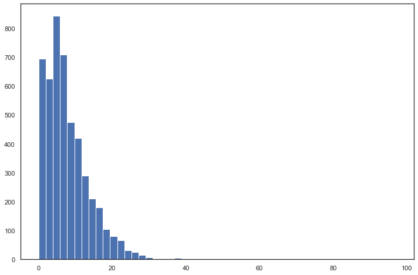

```python
plt.figure(figsize=(12,8))
plt.hist(n_keywords, bins=50)
```

```python
n_keywords.value_counts().sort_index()
```

```
0     407
1     287
2     282
3     344
4     387
5     456
6     383
7     326
8     248
9     227
10    199
11    220
12    161
13    128
14    103
```

[output cut: 28 more lines]

```python
tmdb_df[n_keywords==97]
```

|  | id | title | keywords | original_language | original_title | overview | popularity | production_companies | production_countries | release_date | ... | cast_gender_m | crew_num | director_id | director_name | genre_0_id | genre_0_name | genre_1_id | genre_1_name | genre_2_id | genre_2_name |
| --- | --- | --- | --- | --- | --- | --- | --- | --- | --- | --- | --- | --- | --- | --- | --- | --- | --- | --- | --- | --- | --- |
| 2428 | 26390 | Brooklyn's Finest | id name 0 255 ... | en | Brooklyn's Finest | Enforcing the law within the notoriously rough... | 18.790102 | name id 0 ... | iso_3166_1 name 0 ... | 2009-01-16 | ... | 15 | 77 | 20907 | Antoine Fuqua | 80 | Crime | 18 | Drama | 53 | Thriller |

1 rows × 37 columns

```python
tmdb_df.iloc[2428]['keywords'].head(30)
```

|  | id | name |
| --- | --- | --- |
| 0 | 255 | male nudity |
| 1 | 293 | female nudity |
| 2 | 331 | tattoo |
| 3 | 395 | gambling |
| 4 | 417 | corruption |
| 5 | 494 | father son relationship |
| 6 | 549 | prostitute |
| 7 | 642 | robbery |
| 8 | 703 | detective |
| 9 | 796 | police brutality |
| 10 | 1157 | wife husband relationship |
| 11 | 1317 | card game |
| 12 | 1333 | desperation |
| 13 | 1568 | undercover |
| 14 | 1930 | kidnapping |
| 15 | 2231 | drug dealer |
| 16 | 4948 | retirement |
| 17 | 4959 | death of a friend |
| 18 | 5504 | asthma |
| 19 | 6149 | police |
| 20 | 7410 | fellatio |
| 21 | 8636 | blood splatter |
| 22 | 9748 | revenge |
| 23 | 9758 | deception |
| 24 | 9826 | murder |
| 25 | 10085 | betrayal |
| 26 | 10093 | priest |
| 27 | 10688 | breast |
| 28 | 10856 | bag of money |
| 29 | 10950 | shootout |

```python
def main_keywords(keywords, n_main=5):
    keywords_pattern = np.array([np.nan, None])
    if keywords.empty:
        return np.tile(keywords_pattern, n_main)
    else:
        n_keywords = len(keywords)
        keywords_extract = keywords.loc[:min(n_main-1, n_keywords), ['id','name']].values.flatten()

    return np.append(keywords_extract, np.tile(keywords_pattern, max(0, n_main-n_keywords)))
```

```python
tmdb_df_main_keywords = tmdb_df['keywords'].apply(main_keywords)
```

```python
main_keywords_columns = [['keyword_'+str(i)+'_id', 'keyword_'+str(i)+'_name'] for i in range(5)]
main_keywords_columns = list(chain.from_iterable(main_keywords_columns))

main_keywords_df = pd.DataFrame(np.array(tmdb_df_main_keywords.values.tolist()), columns=main_keywords_columns)
main_keywords_df
```

|  | keyword_0_id | keyword_0_name | keyword_1_id | keyword_1_name | keyword_2_id | keyword_2_name | keyword_3_id | keyword_3_name | keyword_4_id | keyword_4_name |
| --- | --- | --- | --- | --- | --- | --- | --- | --- | --- | --- |
| 0 | 1463 | culture clash | 2964 | future | 3386 | space war | 3388 | space colony | 3679 | society |
| 1 | 270 | ocean | 726 | drug abuse | 911 | exotic island | 1319 | east india trading company | 2038 | love of one's life |
| 2 | 470 | spy | 818 | based on novel | 4289 | secret agent | 9663 | sequel | 14555 | mi6 |
| 3 | 849 | dc comics | 853 | crime fighter | 949 | terrorist | 1308 | secret identity | 1437 | burglar |
| 4 | 818 | based on novel | 839 | mars | 1456 | medallion | 3801 | space travel | 7376 | princess |
| ... | ... | ... | ... | ... | ... | ... | ... | ... | ... | ... |
| 4786 | 5616 | united states–mexico barrier | 33649 | legs | 162740 | arms | 187891 | paper knife | 206558 | guitar case |
| 4787 | NaN | None | NaN | None | NaN | None | NaN | None | NaN | None |
| 4788 | 248 | date | 699 | love at first sight | 2398 | narration | 5340 | investigation | 34051 | team |
| 4789 | NaN | None | NaN | None | NaN | None | NaN | None | NaN | None |
| 4790 | 1523 | obsession | 2249 | camcorder | 9986 | crush | 11223 | dream girl | NaN | None |

4791 rows × 10 columns

```python
tmdb_df = tmdb_df.join(main_keywords_df)
tmdb_df.head()
```

|  | id | title | keywords | original_language | original_title | overview | popularity | production_companies | production_countries | release_date | ... | keyword_0_id | keyword_0_name | keyword_1_id | keyword_1_name | keyword_2_id | keyword_2_name | keyword_3_id | keyword_3_name | keyword_4_id | keyword_4_name |
| --- | --- | --- | --- | --- | --- | --- | --- | --- | --- | --- | --- | --- | --- | --- | --- | --- | --- | --- | --- | --- | --- |
| 0 | 19995 | Avatar | id name 0 1463 cult... | en | Avatar | In the 22nd century, a paraplegic Marine is di... | 150.437577 | name id... | iso_3166_1 name 0 ... | 2009-12-10 | ... | 1463 | culture clash | 2964 | future | 3386 | space war | 3388 | space colony | 3679 | society |
| 1 | 285 | Pirates of the Caribbean: At World's End | id name 0 ... | en | Pirates of the Caribbean: At World's End | Captain Barbossa, long believed to be dead, ha... | 139.082615 | name id 0 Walt D... | iso_3166_1 name 0 ... | 2007-05-19 | ... | 270 | ocean | 726 | drug abuse | 911 | exotic island | 1319 | east india trading company | 2038 | love of one's life |
| 2 | 206647 | Spectre | id name 0 470 ... | en | Spectre | A cryptic message from Bond’s past sends him o... | 107.376788 | name id 0 Columbia Pictur... | iso_3166_1 name 0 ... | 2015-10-26 | ... | 470 | spy | 818 | based on novel | 4289 | secret agent | 9663 | sequel | 14555 | mi6 |
| 3 | 49026 | The Dark Knight Rises | id name 0 849 ... | en | The Dark Knight Rises | Following the death of District Attorney Harve... | 112.312950 | name id 0 Legendary Pictu... | iso_3166_1 name 0 ... | 2012-07-16 | ... | 849 | dc comics | 853 | crime fighter | 949 | terrorist | 1308 | secret identity | 1437 | burglar |
| 4 | 49529 | John Carter | id name 0 818 ... | en | John Carter | John Carter is a war-weary, former military ca... | 43.926995 | name id 0 Walt Disney Pic... | iso_3166_1 name 0 ... | 2012-03-07 | ... | 818 | based on novel | 839 | mars | 1456 | medallion | 3801 | space travel | 7376 | princess |

5 rows × 47 columns

```python
tmdb_df.drop(['keywords'], axis=1, inplace=True)
```

### Column 7 - "Original Language"

```python
tmdb_df['original_language'].value_counts()
```

```
en    4496
fr      70
es      32
zh      27
de      26
hi      19
ja      16
it      13
cn      12
ru      11
ko      11
pt       9
da       7
sv       5
fa       4
nl       4
he       3
th       3
id       2
ta       2
ar       2
ro       2
is       1
ky       1
hu       1
nb       1
xx       1
sl       1
no       1
tr       1
ps       1
el       1
cs       1
vi       1
te       1
af       1
pl       1
Name: original_language, dtype: int64
```

### Column 8 - "Original Title"

```python
np.sum(tmdb_df['title']!=tmdb_df['original_title'])
```

```
261
```

261 moives has a title different from their original ones

```python
np.sum(tmdb_df['original_language']!='en')
```

```
295
```

295 moives is not originally English

```python
np.sum((tmdb_df['title']!=tmdb_df['original_title'])|(tmdb_df['original_language']!='en'))
```

```
339
```

```python
np.sum((tmdb_df['title']!=tmdb_df['original_title'])&(tmdb_df['original_language']!='en'))
```

```
217
```

```python
tmdb_df[(tmdb_df['title']!=tmdb_df['original_title'])&(tmdb_df['original_language']!='en')].head()
```

|  | id | title | original_language | original_title | overview | popularity | production_companies | production_countries | release_date | revenue | ... | keyword_0_id | keyword_0_name | keyword_1_id | keyword_1_name | keyword_2_id | keyword_2_name | keyword_3_id | keyword_3_name | keyword_4_id | keyword_4_name |
| --- | --- | --- | --- | --- | --- | --- | --- | --- | --- | --- | --- | --- | --- | --- | --- | --- | --- | --- | --- | --- | --- |
| 97 | 315011 | Shin Godzilla | ja | シン・ゴジラ | From the mind behind Evangelion comes a hit la... | 9.476999 | name id 0 Cine Bazar 589... | iso_3166_1 name 0 JP Japan | 2016-07-29 | 77000000 | ... | 1299 | monster | 7671 | godzilla | 11100 | giant monster | 14796 | destruction | 161791 | kaiju |
| 235 | 2395 | Asterix at the Olympic Games | fr | Astérix aux Jeux Olympiques | Astérix and Obélix have to win the Olympic Gam... | 20.344364 | ... | iso_3166_1 name 0 BE Belgium 1 ... | 2008-01-13 | 132900000 | ... | 271 | competition | 1200 | greece | 1396 | colosseum | 2070 | olympic games | 2280 | emperor |
| 317 | 76758 | The Flowers of War | zh | 金陵十三釵 | A Westerner finds refuge with a group of women... | 12.516546 | name id 0 ... | iso_3166_1 name 0 CN Chin... | 2011-12-15 | 95311434 | ... | 173251 | forced prostitution | 173254 | child rape | NaN | None | NaN | None | NaN | None |
| 474 | 330770 | Evolution | fr | Évolution | 11-year-old Nicolas lives with his mother in a... | 3.300061 | ... | iso_3166_1 name 0 BE Belgium 1 ... | 2015-09-14 | 0 | ... | 428 | nurse | 658 | sea | 966 | beach | 5202 | boy | 10721 | pregnant |
| 492 | 293644 | Top Cat Begins | es | Don Gato: El inicio de la pandilla | Top Cat has arrived to charm his way into your... | 0.719996 | name id 0 ... | iso_3166_1 name 0 IN India 1 ... | 2015-10-30 | 0 | ... | 209714 | 3d | NaN | None | NaN | None | NaN | None | NaN | None |

5 rows × 46 columns

217 moives originally not in English has a different title in the data base

```python
np.sum((tmdb_df['title']!=tmdb_df['original_title'])&(tmdb_df['original_language']=='en'))
```

```
44
```

```python
tmdb_df[(tmdb_df['title']!=tmdb_df['original_title'])&(tmdb_df['original_language']=='en')].head()
```

|  | id | title | original_language | original_title | overview | popularity | production_companies | production_countries | release_date | revenue | ... | keyword_0_id | keyword_0_name | keyword_1_id | keyword_1_name | keyword_2_id | keyword_2_name | keyword_3_id | keyword_3_name | keyword_4_id | keyword_4_name |
| --- | --- | --- | --- | --- | --- | --- | --- | --- | --- | --- | --- | --- | --- | --- | --- | --- | --- | --- | --- | --- | --- |
| 215 | 1979 | Fantastic 4: Rise of the Silver Surfer | en | 4: Rise of the Silver Surfer | The Fantastic Four return to the big screen as... | 60.810723 | name ... | iso_3166_1 name 0 ... | 2007-06-13 | 289047763 | ... | 657 | fire | 720 | helicopter | 1671 | surfboard | 2546 | mask | 3376 | satellite |
| 488 | 9992 | Arthur and the Invisibles | en | Arthur et les Minimoys | Arthur is a spirited ten-year old whose parent... | 27.097932 | name id 0 C... | iso_3166_1 name 0 FR France | 2006-12-13 | 107944236 | ... | 1158 | grandfather grandson relationship | 4391 | wretch | 6956 | treasure hunt | 10941 | disappearance | 18035 | family |
| 561 | 1997 | Two Brothers | en | Deux frères | Two tigers are separated as cubs and taken int... | 8.884318 | name id 0 Pathé ... | iso_3166_1 name 0 FR ... | 2004-04-07 | 62172050 | ... | 380 | brother brother relationship | 963 | loss of brother | 2960 | cambodia | 3713 | chase | 4809 | tiger |
| 719 | 13576 | This Is It | en | Michael Jackson's This Is It | A compilation of interviews, rehearsals and ba... | 15.798622 | name id 0 Columbia Pictures 5 | iso_3166_1 name 0 ... | 2009-10-28 | 0 | ... | 3490 | pop star | 6027 | music | 6029 | concert | 179430 | aftercreditsstinger | 179431 | duringcreditsstinger |
| 1255 | 80278 | The Impossible | en | Lo imposible | In December 2004, close-knit family Maria, Hen... | 47.559928 | ... | iso_3166_1 name 0 ... | 2012-09-09 | 180274123 | ... | 3434 | thailand | 6941 | tsunami | 14724 | family vacation | 181012 | tidal wave | 188351 | catastrophe |

5 rows × 46 columns

44 movies have diffierent title not because of English translation, some of which has a foreign name though it is originally English

```python
np.sum((tmdb_df['title']==tmdb_df['original_title'])&(tmdb_df['original_language']!='en'))
```

```
78
```

```python
tmdb_df[(tmdb_df['title']==tmdb_df['original_title'])&(tmdb_df['original_language']!='en')].head()
```

|  | id | title | original_language | original_title | overview | popularity | production_companies | production_countries | release_date | revenue | ... | keyword_0_id | keyword_0_name | keyword_1_id | keyword_1_name | keyword_2_id | keyword_2_name | keyword_3_id | keyword_3_name | keyword_4_id | keyword_4_name |
| --- | --- | --- | --- | --- | --- | --- | --- | --- | --- | --- | --- | --- | --- | --- | --- | --- | --- | --- | --- | --- | --- |
| 1011 | 53953 | The Tooth Fairy | de | The Tooth Fairy | A woman and her daughter (Nicole Muñoz) encoun... | 0.716764 | Empty DataFrame Columns: [] Index: [] | Empty DataFrame Columns: [] Index: [] | 2006-08-08 | 0 | ... | 10292 | gore | 12339 | slasher | 14768 | single mother | 33597 | tooth fairy | 33598 | woodchipper |
| 1286 | 110415 | Snowpiercer | ko | Snowpiercer | In a future where a failed global-warming expe... | 64.238688 | name id 0 CJ Entertainment... | iso_3166_1 name 0 ... | 2013-08-01 | 86758912 | ... | 494 | father son relationship | 714 | child labour | 1411 | brothel | 1442 | winter | 1501 | allegory |
| 1290 | 256040 | Baahubali: The Beginning | te | Baahubali: The Beginning | The young Shivudu is left as a foundling in a ... | 16.254032 | name id 0 Arka Media Works... | iso_3166_1 name 0 IN India | 2015-07-10 | 100000000 | ... | 4152 | kingdom | 6091 | war | 10540 | bollywood | 216931 | medieval india | 216932 | ancient india |
| 1306 | 257932 | Dragon Nest: Warriors' Dawn | zh | Dragon Nest: Warriors' Dawn | The land of Altera has observed an uneasy peac... | 5.057695 | name id 0 Mili Pictures 60714 | iso_3166_1 name 0 ... | 2014-05-20 | 0 | ... | NaN | None | NaN | None | NaN | None | NaN | None | NaN | None |
| 1353 | 75531 | Isn't She Great | de | Isn't She Great | An unsuccessful over-the-top actress becomes a... | 1.068453 | ... | iso_3166_1 name 0 ... | 2000-01-28 | 3003296 | ... | 1646 | autism | 165340 | based on article | NaN | None | NaN | None | NaN | None |

5 rows × 46 columns

78 movies, though originally not English, have a English original title

```python
tmdb_df.drop(['original_title'], axis=1, inplace=True)
```

### Column 9 - "Overview"

```python
tmdb_df['overview'].str.len().describe()
```

```
count    4791.000000
mean      305.552077
std       162.652607
min        23.000000
25%       178.000000
50%       284.000000
75%       392.000000
max      1000.000000
Name: overview, dtype: float64
```

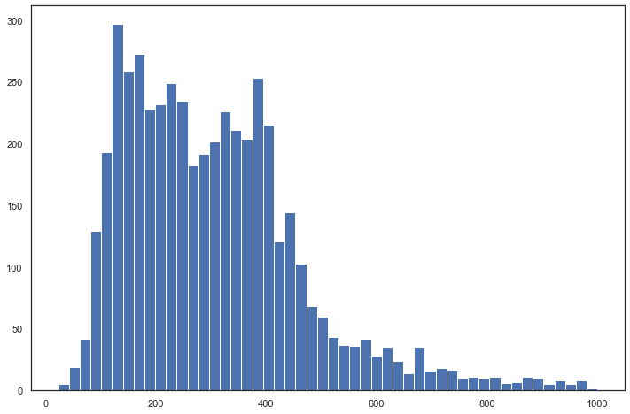

```python
plt.figure(figsize=(12,8))
plt.hist(tmdb_df['overview'].str.len(), bins=50)
```

### Column 10 - "Popularity"

```python
tmdb_df['popularity'].describe()
```

```
count    4791.000000
mean       21.545058
std        31.838973
min         0.000372
25%         4.744311
50%        12.971122
75%        28.375282
max       875.581305
Name: popularity, dtype: float64
```

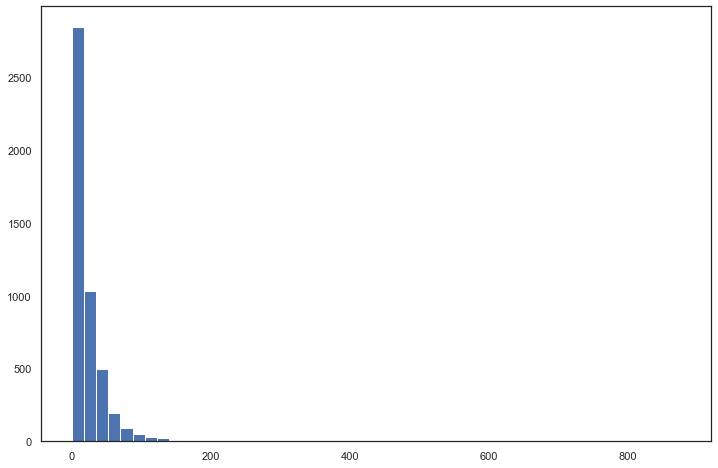

```python
plt.figure(figsize=(12,8))
plt.hist(tmdb_df['popularity'], bins=50)
```

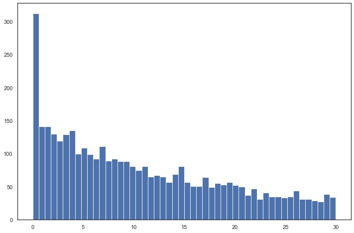

```python
plt.figure(figsize=(12,8))
plt.hist(tmdb_df[tmdb_df['popularity']<30]['popularity'], bins=50)
```

```python
np.sum(tmdb_df['popularity']<1)
```

```
409
```

```python
np.sum(tmdb_df['popularity']<10)
```

```
2027
```

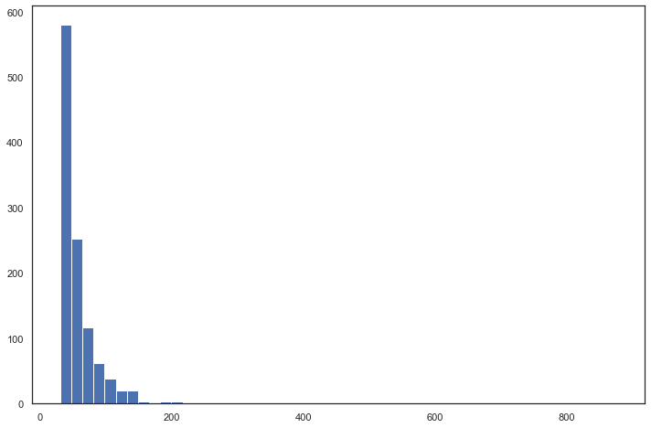

```python
plt.figure(figsize=(12,8))
plt.hist(tmdb_df[tmdb_df['popularity']>30]['popularity'], bins=50)
```

```python
tmdb_df.sort_values(by=['popularity'], ascending=False).head(10)
```

|  | id | title | original_language | overview | popularity | production_companies | production_countries | release_date | revenue | runtime | ... | keyword_0_id | keyword_0_name | keyword_1_id | keyword_1_name | keyword_2_id | keyword_2_name | keyword_3_id | keyword_3_name | keyword_4_id | keyword_4_name |
| --- | --- | --- | --- | --- | --- | --- | --- | --- | --- | --- | --- | --- | --- | --- | --- | --- | --- | --- | --- | --- | --- |
| 546 | 211672 | Minions | en | Minions Stuart, Kevin and Bob are recruited by... | 875.581305 | name id 0 ... | iso_3166_1 name 0 ... | 2015-06-17 | 1156730962 | 91.0 | ... | 3487 | assistant | 179430 | aftercreditsstinger | 179431 | duringcreditsstinger | 189481 | evil mastermind | 190999 | minions |
| 95 | 157336 | Interstellar | en | Interstellar chronicles the adventures of a gr... | 724.247784 | name id 0 Paramo... | iso_3166_1 name 0 ... | 2014-11-05 | 675120017 | 169.0 | ... | 83 | saving the world | 310 | artificial intelligence | 494 | father son relationship | 641 | single parent | 1432 | nasa |
| 788 | 293660 | Deadpool | en | Deadpool tells the origin story of former Spec... | 514.569956 | name ... | iso_3166_1 name 0 ... | 2016-02-09 | 783112979 | 108.0 | ... | 2095 | anti hero | 3070 | mercenary | 8828 | marvel comic | 9715 | superhero | 9717 | based on comic book |
| 94 | 118340 | Guardians of the Galaxy | en | Light years from Earth, 26 years after being a... | 481.098624 | name id 0 ... | iso_3166_1 name 0 ... | 2014-07-30 | 773328629 | 121.0 | ... | 8828 | marvel comic | 9831 | spaceship | 9882 | space | 12405 | outer space | 13014 | orphan |
| 127 | 76341 | Mad Max: Fury Road | en | An apocalyptic story set in the furthest reach... | 434.278564 | name id 0 Villag... | iso_3166_1 name 0 ... | 2015-05-13 | 378858340 | 120.0 | ... | 2964 | future | 3713 | chase | 4458 | post-apocalyptic | 4565 | dystopia | 5657 | australia |
| 28 | 135397 | Jurassic World | en | Twenty-two years after the events of Jurassic ... | 418.708552 | name id 0 Univ... | iso_3166_1 name 0 ... | 2015-06-09 | 1513528810 | 124.0 | ... | 1299 | monster | 1718 | dna | 1720 | tyrannosaurus rex | 1766 | velociraptor | 2041 | island |
| 199 | 22 | Pirates of the Caribbean: The Curse of the Bla... | en | Jack Sparrow, a freewheeling 17th-century pira... | 271.972889 | name id 0 Walt Dis... | iso_3166_1 name 0 ... | 2003-07-09 | 655011224 | 143.0 | ... | 911 | exotic island | 1318 | blacksmith | 1319 | east india trading company | 1321 | gold | 1459 | marriage proposal |
| 82 | 119450 | Dawn of the Planet of the Apes | en | A group of scientists in San Francisco struggl... | 243.791743 | name id 0 Ingen... | iso_3166_1 name 0 ... | 2014-06-26 | 710644566 | 130.0 | ... | 3077 | leader | 4090 | colony | 4458 | post-apocalyptic | 4565 | dystopia | 5774 | forest |
| 200 | 131631 | The Hunger Games: Mockingjay - Part 1 | en | Katniss Everdeen reluctantly becomes the symbo... | 206.227151 | name id 0 Lionsgate 1632 1 C... | iso_3166_1 name 0 ... | 2014-11-18 | 752100229 | 123.0 | ... | 836 | resistance | 4458 | post-apocalyptic | 4565 | dystopia | 6091 | war | 9663 | sequel |
| 88 | 177572 | Big Hero 6 | en | The special bond that develops between plus-si... | 203.734590 | name id 0 ... | iso_3166_1 name 0 ... | 2014-10-24 | 652105443 | 102.0 | ... | 380 | brother brother relationship | 1701 | hero | 2276 | talent | 9748 | revenge | 12392 | best friend |

10 rows × 45 columns

### Column 11 - "Production Companies"

```python
avatar_production_companies = tmdb_df.iloc[0]['production_companies']
avatar_production_companies
```

|  | name | id |
| --- | --- | --- |
| 0 | Ingenious Film Partners | 289 |
| 1 | Twentieth Century Fox Film Corporation | 306 |
| 2 | Dune Entertainment | 444 |
| 3 | Lightstorm Entertainment | 574 |

```python
n_production_companies = tmdb_df['production_companies'].apply(len)
n_production_companies
```

```
0       4
1       3
2       3
3       4
4       1
       ..
4786    1
4787    0
4788    2
4789    0
4790    2
Name: production_companies, Length: 4791, dtype: int64
```

```python
n_production_companies.describe()
```

```
count    4791.000000
mean        2.853058
std         2.230953
min         0.000000
25%         1.000000
50%         2.000000
75%         4.000000
max        26.000000
Name: production_companies, dtype: float64
```

```python
n_production_companies.value_counts().sort_index()
```

```
0      343
1     1063
2     1062
3      916
4      587
5      320
6      218
7      118
8       61
9       46
10      16
11      12
12       5
13       3
14       4
15       2
16       6
17       4
18       1
19       1
21       1
25       1
26       1
Name: production_companies, dtype: int64
```

```python
tmdb_df[n_production_companies==26]
```

|  | id | title | original_language | overview | popularity | production_companies | production_countries | release_date | revenue | runtime | ... | keyword_0_id | keyword_0_name | keyword_1_id | keyword_1_name | keyword_2_id | keyword_2_name | keyword_3_id | keyword_3_name | keyword_4_id | keyword_4_name |
| --- | --- | --- | --- | --- | --- | --- | --- | --- | --- | --- | --- | --- | --- | --- | --- | --- | --- | --- | --- | --- | --- |
| 2798 | 16 | Dancer in the Dark | en | Selma, a Czech immigrant on the verge of blind... | 22.022228 | nam... | iso_3166_1 name 0 ... | 2000-05-17 | 40031879 | 140.0 | ... | 30 | individual | 246 | dancing | 279 | usa | 642 | robbery | 730 | factory worker |

1 rows × 45 columns

```python
tmdb_df.iloc[2798]['production_companies']
```

|  | name | id |
| --- | --- | --- |
| 0 | Fine Line Features | 8 |
| 1 | Zentropa Entertainments | 76 |
| 2 | Danmarks Radio (DR) | 119 |
| 3 | SVT Drama | 157 |
| 4 | Arte | 201 |
| 5 | Memfis Film | 321 |
| 6 | France 3 Cinéma | 591 |
| 7 | Angel films | 2996 |
| 8 | TV 1000 | 4524 |
| 9 | Canal+ | 5358 |
| 10 | Constantin Film Produktion | 5755 |
| 11 | Yleisradio (YLE) | 5975 |
| 12 | Arte France Cinéma | 6916 |
| 13 | Westdeutscher Rundfunk (WDR) | 7025 |
| 14 | Blind Spot Pictures Oy | 7330 |
| 15 | Vrijzinnig Protestantse Radio Omroep (VPRO) | 8659 |
| 16 | Film4 | 9349 |
| 17 | Liberator Productions | 11239 |
| 18 | Icelandic Film | 14937 |
| 19 | Film i Väst | 17513 |
| 20 | Pain Unlimited GmbH Filmproduktion | 30268 |
| 21 | Trust Film Svenska | 53667 |
| 22 | Cinematograph A/S | 53668 |
| 23 | What Else? B.V | 53669 |
| 24 | Filmek A/S | 53670 |
| 25 | Lantia Cinema & Audiovisivi | 53671 |

```python
tmdb_df['production_companies_num']=n_production_companies
```

```python
def main_pro_coms(pro_coms, n_main=2):
    pro_coms_pattern = np.array([np.nan, None])
    if pro_coms.empty:
        return np.tile(pro_coms_pattern, n_main)
    else:
        n_pro_coms = len(pro_coms)
        pro_coms_extract = pro_coms.loc[:min(n_main-1, n_pro_coms), ['id','name']].values.flatten()

    return np.append(pro_coms_extract, np.tile(pro_coms_pattern, max(0, n_main-n_pro_coms)))
```

```python
tmdb_df_main_pro_coms = tmdb_df['production_companies'].apply(main_pro_coms)
```

```python
main_pro_coms_columns = [['production_company_'+str(i)+'_id', 'production_company_'+str(i)+'_name']
                         for i in range(2)]
main_pro_coms_columns = list(chain.from_iterable(main_pro_coms_columns))

main_pro_coms_df = pd.DataFrame(np.array(tmdb_df_main_pro_coms.values.tolist()), columns=main_pro_coms_columns)
main_pro_coms_df
```

|  | production_company_0_id | production_company_0_name | production_company_1_id | production_company_1_name |
| --- | --- | --- | --- | --- |
| 0 | 289 | Ingenious Film Partners | 306 | Twentieth Century Fox Film Corporation |
| 1 | 2 | Walt Disney Pictures | 130 | Jerry Bruckheimer Films |
| 2 | 5 | Columbia Pictures | 10761 | Danjaq |
| 3 | 923 | Legendary Pictures | 6194 | Warner Bros. |
| 4 | 2 | Walt Disney Pictures | NaN | None |
| ... | ... | ... | ... | ... |
| 4786 | 5 | Columbia Pictures | NaN | None |
| 4787 | NaN | None | NaN | None |
| 4788 | 3958 | Front Street Pictures | 6438 | Muse Entertainment Enterprises |
| 4789 | NaN | None | NaN | None |
| 4790 | 87986 | rusty bear entertainment | 87987 | lucky crow films |

4791 rows × 4 columns

```python
tmdb_df = tmdb_df.join(main_pro_coms_df)
tmdb_df.head()
```

|  | id | title | original_language | overview | popularity | production_companies | production_countries | release_date | revenue | runtime | ... | keyword_2_name | keyword_3_id | keyword_3_name | keyword_4_id | keyword_4_name | production_companies_num | production_company_0_id | production_company_0_name | production_company_1_id | production_company_1_name |
| --- | --- | --- | --- | --- | --- | --- | --- | --- | --- | --- | --- | --- | --- | --- | --- | --- | --- | --- | --- | --- | --- |
| 0 | 19995 | Avatar | en | In the 22nd century, a paraplegic Marine is di... | 150.437577 | name id... | iso_3166_1 name 0 ... | 2009-12-10 | 2787965087 | 162.0 | ... | space war | 3388 | space colony | 3679 | society | 4 | 289 | Ingenious Film Partners | 306 | Twentieth Century Fox Film Corporation |
| 1 | 285 | Pirates of the Caribbean: At World's End | en | Captain Barbossa, long believed to be dead, ha... | 139.082615 | name id 0 Walt D... | iso_3166_1 name 0 ... | 2007-05-19 | 961000000 | 169.0 | ... | exotic island | 1319 | east india trading company | 2038 | love of one's life | 3 | 2 | Walt Disney Pictures | 130 | Jerry Bruckheimer Films |
| 2 | 206647 | Spectre | en | A cryptic message from Bond’s past sends him o... | 107.376788 | name id 0 Columbia Pictur... | iso_3166_1 name 0 ... | 2015-10-26 | 880674609 | 148.0 | ... | secret agent | 9663 | sequel | 14555 | mi6 | 3 | 5 | Columbia Pictures | 10761 | Danjaq |
| 3 | 49026 | The Dark Knight Rises | en | Following the death of District Attorney Harve... | 112.312950 | name id 0 Legendary Pictu... | iso_3166_1 name 0 ... | 2012-07-16 | 1084939099 | 165.0 | ... | terrorist | 1308 | secret identity | 1437 | burglar | 4 | 923 | Legendary Pictures | 6194 | Warner Bros. |
| 4 | 49529 | John Carter | en | John Carter is a war-weary, former military ca... | 43.926995 | name id 0 Walt Disney Pic... | iso_3166_1 name 0 ... | 2012-03-07 | 284139100 | 132.0 | ... | medallion | 3801 | space travel | 7376 | princess | 1 | 2 | Walt Disney Pictures | NaN | None |

5 rows × 50 columns

```python
tmdb_df.drop(['production_companies'], axis=1, inplace=True)
```

### Column 12 - "Production Countries"

```python
avatar_production_countries = tmdb_df.iloc[0]['production_countries']
avatar_production_countries
```

|  | iso_3166_1 | name |
| --- | --- | --- |
| 0 | US | United States of America |
| 1 | GB | United Kingdom |

```python
n_production_countries = tmdb_df['production_countries'].apply(len)
n_production_countries
```

```
0       2
1       1
2       2
3       1
4       1
       ..
4786    2
4787    0
4788    1
4789    2
4790    1
Name: production_countries, Length: 4791, dtype: int64
```

```python
n_production_countries.describe()
```

```
count    4791.000000
mean        1.341891
std         0.799005
min         0.000000
25%         1.000000
50%         1.000000
75%         2.000000
max        12.000000
Name: production_countries, dtype: float64
```

```python
n_production_countries.value_counts().sort_index()
```

```
0      169
1     3376
2      851
3      275
4       93
5       20
6        2
7        2
8        2
12       1
Name: production_countries, dtype: int64
```

```python
tmdb_df[n_production_countries==12]
```

|  | id | title | original_language | overview | popularity | production_countries | release_date | revenue | runtime | spoken_languages | ... | keyword_2_name | keyword_3_id | keyword_3_name | keyword_4_id | keyword_4_name | production_companies_num | production_company_0_id | production_company_0_name | production_company_1_id | production_company_1_name |
| --- | --- | --- | --- | --- | --- | --- | --- | --- | --- | --- | --- | --- | --- | --- | --- | --- | --- | --- | --- | --- | --- |
| 2798 | 16 | Dancer in the Dark | en | Selma, a Czech immigrant on the verge of blind... | 22.022228 | iso_3166_1 name 0 ... | 2000-05-17 | 40031879 | 140.0 | iso_639_1 name 0 en English | ... | usa | 642 | robbery | 730 | factory worker | 26 | 8 | Fine Line Features | 76 | Zentropa Entertainments |

1 rows × 49 columns

```python
tmdb_df.iloc[2798]['production_countries']
```

|  | iso_3166_1 | name |
| --- | --- | --- |
| 0 | AR | Argentina |
| 1 | DK | Denmark |
| 2 | FI | Finland |
| 3 | FR | France |
| 4 | DE | Germany |
| 5 | IS | Iceland |
| 6 | IT | Italy |
| 7 | NL | Netherlands |
| 8 | NO | Norway |
| 9 | SE | Sweden |
| 10 | GB | United Kingdom |
| 11 | US | United States of America |

```python
tmdb_df['production_countries_num']=n_production_countries
```

```python
def main_pro_couns(pro_couns):
    if pro_couns.empty:
        return np.array([np.nan, None])
    else:
        return pro_couns.loc[0, ['iso_3166_1','name']].values.flatten()
```

```python
tmdb_df_main_pro_couns = tmdb_df['production_countries'].apply(main_pro_couns)
```

```python
main_pro_couns_columns = ['production_country_code', 'production_country_name']

main_pro_couns_df = pd.DataFrame(list(tmdb_df_main_pro_couns), columns=main_pro_couns_columns)
main_pro_couns_df
```

|  | production_country_code | production_country_name |
| --- | --- | --- |
| 0 | US | United States of America |
| 1 | US | United States of America |
| 2 | GB | United Kingdom |
| 3 | US | United States of America |
| 4 | US | United States of America |
| ... | ... | ... |
| 4786 | MX | Mexico |
| 4787 | NaN | None |
| 4788 | US | United States of America |
| 4789 | US | United States of America |
| 4790 | US | United States of America |

4791 rows × 2 columns

```python
tmdb_df = tmdb_df.join(main_pro_couns_df)
tmdb_df.head()
```

|  | id | title | original_language | overview | popularity | production_countries | release_date | revenue | runtime | spoken_languages | ... | keyword_4_id | keyword_4_name | production_companies_num | production_company_0_id | production_company_0_name | production_company_1_id | production_company_1_name | production_countries_num | production_country_code | production_country_name |
| --- | --- | --- | --- | --- | --- | --- | --- | --- | --- | --- | --- | --- | --- | --- | --- | --- | --- | --- | --- | --- | --- |
| 0 | 19995 | Avatar | en | In the 22nd century, a paraplegic Marine is di... | 150.437577 | iso_3166_1 name 0 ... | 2009-12-10 | 2787965087 | 162.0 | iso_639_1 name 0 en English 1 ... | ... | 3679 | society | 4 | 289 | Ingenious Film Partners | 306 | Twentieth Century Fox Film Corporation | 2 | US | United States of America |
| 1 | 285 | Pirates of the Caribbean: At World's End | en | Captain Barbossa, long believed to be dead, ha... | 139.082615 | iso_3166_1 name 0 ... | 2007-05-19 | 961000000 | 169.0 | iso_639_1 name 0 en English | ... | 2038 | love of one's life | 3 | 2 | Walt Disney Pictures | 130 | Jerry Bruckheimer Films | 1 | US | United States of America |
| 2 | 206647 | Spectre | en | A cryptic message from Bond’s past sends him o... | 107.376788 | iso_3166_1 name 0 ... | 2015-10-26 | 880674609 | 148.0 | iso_639_1 name 0 fr Français 1 ... | ... | 14555 | mi6 | 3 | 5 | Columbia Pictures | 10761 | Danjaq | 2 | GB | United Kingdom |
| 3 | 49026 | The Dark Knight Rises | en | Following the death of District Attorney Harve... | 112.312950 | iso_3166_1 name 0 ... | 2012-07-16 | 1084939099 | 165.0 | iso_639_1 name 0 en English | ... | 1437 | burglar | 4 | 923 | Legendary Pictures | 6194 | Warner Bros. | 1 | US | United States of America |
| 4 | 49529 | John Carter | en | John Carter is a war-weary, former military ca... | 43.926995 | iso_3166_1 name 0 ... | 2012-03-07 | 284139100 | 132.0 | iso_639_1 name 0 en English | ... | 7376 | princess | 1 | 2 | Walt Disney Pictures | NaN | None | 1 | US | United States of America |

5 rows × 52 columns

```python
tmdb_df.drop(['production_countries'], axis=1, inplace=True)
```

### Column 13 - "Release Date"

```python
tmdb_df['release_date'].describe()
```

```
count                    4791
unique                   3276
top       2006-01-01 00:00:00
freq                        9
first     1916-09-04 00:00:00
last      2017-02-03 00:00:00
Name: release_date, dtype: object
```

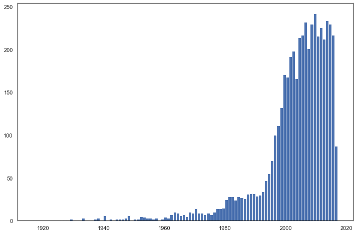

```python
plt.figure(figsize=(12,8))
plt.hist(tmdb_df['release_date'], bins=100)
```

```python
tmdb_df_release_date = tmdb_df[['id', 'title','release_date']]
tmdb_df_release_date = tmdb_df_release_date.set_index(pd.DatetimeIndex(tmdb_df_release_date['release_date']))
tmdb_df_release_date.drop(['release_date'], axis=1, inplace=True)

tmdb_df_release_date
```

| release_date | id | title |
| --- | --- | --- |
| 2009-12-10 | 19995 | Avatar |
| 2007-05-19 | 285 | Pirates of the Caribbean: At World's End |
| 2015-10-26 | 206647 | Spectre |
| 2012-07-16 | 49026 | The Dark Knight Rises |
| 2012-03-07 | 49529 | John Carter |
| ... | ... | ... |
| 1992-09-04 | 9367 | El Mariachi |
| 2011-12-26 | 72766 | Newlyweds |
| 2013-10-13 | 231617 | Signed, Sealed, Delivered |
| 2012-05-03 | 126186 | Shanghai Calling |
| 2005-08-05 | 25975 | My Date with Drew |

4791 rows × 2 columns

```python
tmdb_df_release_year = tmdb_df_release_date.groupby(pd.Grouper(freq='Y'))['id'].count()
tmdb_df_release_year.index.name = 'release_year'
tmdb_df_release_year
```

```
release_year
1916-12-31      1
1917-12-31      0
1918-12-31      0
1919-12-31      0
1920-12-31      0
             ...
2013-12-31    231
2014-12-31    237
2015-12-31    212
2016-12-31    104
2017-12-31      1
Freq: A-DEC, Name: id, Length: 102, dtype: int64
```

```python
tmdb_df_release_year.sort_values(ascending=False).head(15)
```

```
release_year
2009-12-31    246
2014-12-31    237
2006-12-31    235
2013-12-31    231
2008-12-31    227
2010-12-31    225
2011-12-31    221
2005-12-31    216
2015-12-31    212
2012-12-31    208
2004-12-31    204
2002-12-31    203
2007-12-31    195
2001-12-31    183
1999-12-31    171
Name: id, dtype: int64
```

```python
tmdb_df_release_month = tmdb_df_release_date.groupby(pd.Grouper(freq='M'))['id'].count()
tmdb_df_release_month.index.name = 'release_month'
tmdb_df_release_month
```

```
release_month
1916-09-30    1
1916-10-31    0
1916-11-30    0
1916-12-31    0
1917-01-31    0
             ..
2016-10-31    1
2016-11-30    0
2016-12-31    0
2017-01-31    0
2017-02-28    1
Freq: M, Name: id, Length: 1206, dtype: int64
```

```python
tmdb_df_release_month.sort_values(ascending=False).head(30)
```

```
release_month
2009-09-30    44
2011-09-30    39
2006-09-30    36
2005-09-30    35
2004-09-30    34
2012-09-30    31
2008-10-31    30
2006-12-31    29
2008-09-30    28
2010-09-30    28
2009-10-31    28
2014-10-31    28
2002-01-31    27
2011-03-31    26
2013-07-31    26
2015-10-31    26
2015-09-30    26
2013-09-30    26
2012-08-31    25
1999-10-31    25
2005-01-31    25
2006-10-31    25
2009-01-31    25
2007-09-30    25
2008-02-29    24
2006-03-31    24
2014-09-30    24
2014-08-31    24
2013-12-31    24
2006-01-31    23
Name: id, dtype: int64
```

### Column 14 - "Revenue"

```python
tmdb_df['revenue']
```

```
0       2787965087
1        961000000
2        880674609
3       1084939099
4        284139100
           ...
4786       2040920
4787             0
4788             0
4789             0
4790             0
Name: revenue, Length: 4791, dtype: int64
```

```python
tmdb_df['revenue'].describe()
```

```
count    4.791000e+03
mean     8.246650e+07
std      1.630089e+08
min      0.000000e+00
25%      0.000000e+00
50%      1.929414e+07
75%      9.326450e+07
max      2.787965e+09
Name: revenue, dtype: float64
```

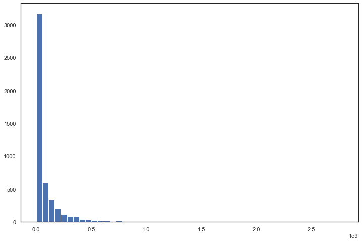

```python
plt.figure(figsize=(12,8))
plt.hist(tmdb_df['revenue'], bins=50)
```

```python
revenue_zero = tmdb_df[tmdb_df['revenue']==0]
len(revenue_zero)
```

```
1416
```

Significant number of movies have zero revenue record, which is unlikely the actual case

```python
revenue_zero.head()
```

|  | id | title | original_language | overview | popularity | release_date | revenue | runtime | spoken_languages | vote_average | ... | keyword_4_id | keyword_4_name | production_companies_num | production_company_0_id | production_company_0_name | production_company_1_id | production_company_1_name | production_countries_num | production_country_code | production_country_name |
| --- | --- | --- | --- | --- | --- | --- | --- | --- | --- | --- | --- | --- | --- | --- | --- | --- | --- | --- | --- | --- | --- |
| 83 | 79698 | The Lovers | en | The Lovers is an epic romance time travel adve... | 2.418535 | 2015-02-13 | 0 | 109.0 | iso_639_1 name 0 en English | 4.8 | ... | NaN | None | 7 | 7299 | Corsan | 8186 | Bliss Media | 3 | AU | Australia |
| 135 | 7978 | The Wolfman | en | Lawrence Talbot, an American man on a visit to... | 21.214571 | 2010-02-11 | 0 | 102.0 | iso_639_1 name 0 en English | 5.5 | ... | 12564 | werewolf | 3 | 33 | Universal Pictures | 4403 | Stuber Productions | 1 | US | United States of America |
| 265 | 10588 | The Cat in the Hat | en | Conrad and Sally Walden are home alone with th... | 18.251129 | 2003-11-21 | 0 | 82.0 | iso_639_1 name 0 en English | 4.9 | ... | 6669 | step father | 3 | 23 | Imagine Entertainment | 27 | DreamWorks SKG | 1 | US | United States of America |
| 309 | 10214 | Son of the Mask | en | Tim Avery, an aspiring cartoonist, finds himse... | 17.815595 | 2005-02-18 | 0 | 94.0 | iso_639_1 name 0 en English | 3.6 | ... | NaN | None | 2 | 12 | New Line Cinema | 3012 | Pathé Distribution | 2 | DE | Germany |
| 376 | 10357 | Volcano | en | An earthquake shatters a peaceful Los Angeles ... | 19.836124 | 1997-04-25 | 0 | 104.0 | iso_639_1 name 0 de Deutsch 1 ... | 5.2 | ... | 12670 | los angeles | 1 | 306 | Twentieth Century Fox Film Corporation | NaN | None | 1 | US | United States of America |

5 rows × 51 columns

```python
tmdb_df.drop(['revenue'], axis=1, inplace=True)
```

### Column 15 - "Runtime"

```python
tmdb_df['runtime'].describe()
```

```
count    4791.000000
mean      106.942392
std        22.519470
min         0.000000
25%        94.000000
50%       104.000000
75%       118.000000
max       338.000000
Name: runtime, dtype: float64
```

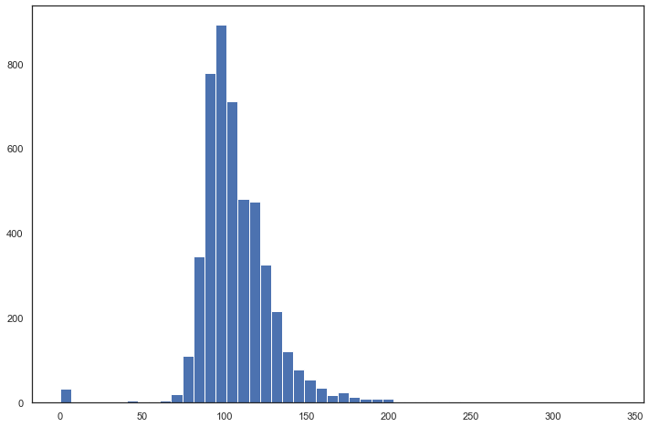

```python
plt.figure(figsize=(12,8))
plt.hist(tmdb_df['runtime'], bins=50)
```

```python
np.sum(tmdb_df['runtime']<(tmdb_df['runtime'].mean()-2*tmdb_df['runtime'].std()))
```

```
42
```

```python
np.sum(tmdb_df['runtime']>(tmdb_df['runtime'].mean()+2*tmdb_df['runtime'].std()))
```

```
166
```

```python
tmdb_df.sort_values(by=['runtime'], ascending=False).head(10)
```

|  | id | title | original_language | overview | popularity | release_date | runtime | spoken_languages | vote_average | vote_count | ... | keyword_4_id | keyword_4_name | production_companies_num | production_company_0_id | production_company_0_name | production_company_1_id | production_company_1_name | production_countries_num | production_country_code | production_country_name |
| --- | --- | --- | --- | --- | --- | --- | --- | --- | --- | --- | --- | --- | --- | --- | --- | --- | --- | --- | --- | --- | --- |
| 2384 | 43434 | Carlos | en | The story of Venezuelan revolutionary, Ilich R... | 1.138383 | 2010-05-19 | 338.0 | iso_639_1 name 0 fr Français 1 ... | 6.7 | 50 | ... | 18232 | opec | 4 | 2254 | Egoli Tossell Film AG | 5358 | Canal+ | 2 | FR | France |
| 2631 | 112430 | The Company | en | Real-life figures from the Cold War era mix wi... | 1.485324 | 2007-08-05 | 276.0 | Empty DataFrame Columns: [] Index: [] | 7.0 | 12 | ... | NaN | None | 0 | NaN | None | NaN | None | 0 | NaN | None |
| 1922 | 10655 | Gettysburg | en | Summer 1863. The Confederacy pushes north into... | 5.529035 | 1993-10-08 | 254.0 | iso_639_1 name 0 en English | 6.6 | 90 | ... | 14643 | battle | 2 | 8609 | TriStar Television | 26560 | Esparza / Katz Productions | 1 | US | United States of America |
| 1125 | 8095 | Cleopatra | en | Historical epic. The triumphs and tragedy of t... | 13.244365 | 1963-06-12 | 248.0 | iso_639_1 name 0 en English ... | 6.7 | 146 | ... | NaN | None | 3 | 306 | Twentieth Century Fox Film Corporation | 11451 | MCL Films S.A. | 3 | GB | United Kingdom |
| 2373 | 10549 | Hamlet | en | Hamlet, Prince of Denmark, returns home to fin... | 9.814785 | 1996-12-25 | 242.0 | iso_639_1 name 0 en English | 7.3 | 117 | ... | 3071 | prince | 2 | 97 | Castle Rock Entertainment | 6189 | Turner Pictures (I) | 2 | GB | United Kingdom |
| 3508 | 183894 | Emma | en | Emma Woodhouse seems to be perfectly content, ... | 2.135689 | 2009-10-11 | 240.0 | iso_639_1 name 0 en English | 7.6 | 38 | ... | NaN | None | 0 | NaN | None | NaN | None | 0 | NaN | None |
| 3811 | 770 | Gone with the Wind | en | An American classic in which a manipulative wo... | 48.982550 | 1939-12-15 | 238.0 | iso_639_1 name 0 en English | 7.7 | 970 | ... | 1459 | marriage proposal | 2 | 1553 | Selznick International Pictures | 8411 | Metro-Goldwyn-Mayer (MGM) | 1 | US | United States of America |
| 1663 | 311 | Once Upon a Time in America | en | A former Prohibition-era Jewish gangster retur... | 49.336397 | 1984-02-16 | 229.0 | iso_639_1 name 0 en English 1 ... | 8.2 | 1069 | ... | 625 | sadistic | 2 | 6194 | Warner Bros. | 7965 | The Ladd Company | 2 | US | United States of America |
| 4489 | 9459 | Woodstock | en | An intimate look at the Woodstock Music & Art ... | 3.409764 | 1970-03-26 | 225.0 | iso_639_1 name 0 en English | 7.1 | 66 | ... | 6447 | woodstock | 2 | 3816 | Wadleigh-Maurice | 6194 | Warner Bros. | 1 | US | United States of America |
| 1109 | 10935 | Heaven's Gate | en | Harvard graduate James Averill (Kris Kristoffe... | 5.380124 | 1980-11-19 | 219.0 | iso_639_1 name 0 en English 1 ... | 6.4 | 55 | ... | 1691 | dance | 2 | 60 | United Artists | 10932 | The Criterion Collection | 1 | US | United States of America |

10 rows × 50 columns

### Column 16 - "Spoken Languages"

```python
avatar_spoken_languages = tmdb_df.iloc[0]['spoken_languages']
avatar_spoken_languages
```

|  | iso_639_1 | name |
| --- | --- | --- |
| 0 | en | English |
| 1 | es | Español |

```python
n_spoken_languages = tmdb_df['spoken_languages'].apply(len)
n_spoken_languages
```

```
0       2
1       1
2       5
3       1
4       1
       ..
4786    1
4787    0
4788    1
4789    1
4790    1
Name: spoken_languages, Length: 4791, dtype: int64
```

```python
n_spoken_languages.describe()
```

```
count    4791.000000
mean        1.446253
std         0.926969
min         0.000000
25%         1.000000
50%         1.000000
75%         2.000000
max         9.000000
Name: spoken_languages, dtype: float64
```

```python
n_spoken_languages.value_counts().sort_index()
```

```
0      82
1    3347
2     841
3     308
4     133
5      51
6      19
7       6
8       3
9       1
Name: spoken_languages, dtype: int64
```

```python
tmdb_df[n_spoken_languages==9]
```

|  | id | title | original_language | overview | popularity | release_date | runtime | spoken_languages | vote_average | vote_count | ... | keyword_4_id | keyword_4_name | production_companies_num | production_company_0_id | production_company_0_name | production_company_1_id | production_company_1_name | production_countries_num | production_country_code | production_country_name |
| --- | --- | --- | --- | --- | --- | --- | --- | --- | --- | --- | --- | --- | --- | --- | --- | --- | --- | --- | --- | --- | --- |
| 59 | 14161 | 2012 | en | Dr. Adrian Helmsley, part of a worldwide geoph... | 45.274225 | 2009-10-10 | 158.0 | iso_639_1 name 0 en English ... | 5.6 | 4903 | ... | 12332 | apocalypse | 4 | 5 | Columbia Pictures | 347 | Centropolis Entertainment | 2 | CA | Canada |

1 rows × 50 columns

```python
tmdb_df.iloc[59]['spoken_languages']
```

|  | iso_639_1 | name |
| --- | --- | --- |
| 0 | en | English |
| 1 | fr | Français |
| 2 | hi | हिन्दी |
| 3 | it | Italiano |
| 4 | la | Latin |
| 5 | zh | 普通话 |
| 6 | pt | Português |
| 7 | ru | Pусский |
| 8 | bo |  |

```python
tmdb_df['spoken_languages_num']=n_spoken_languages
```

```python
def main_spoken_lans(spoken_lans):
    if spoken_lans.empty:
        return np.array([np.nan, None])
    else:
        return spoken_lans.loc[0, ['iso_639_1','name']].values.flatten()
```

```python
tmdb_df_main_spoken_lans = tmdb_df['spoken_languages'].apply(main_spoken_lans)
```

```python
main_spoken_lans_columns = ['spoken_language_code', 'spoken_language_name']

main_spoken_lans_df = pd.DataFrame(list(tmdb_df_main_spoken_lans), columns=main_spoken_lans_columns)
main_spoken_lans_df
```

|  | spoken_language_code | spoken_language_name |
| --- | --- | --- |
| 0 | en | English |
| 1 | en | English |
| 2 | fr | Français |
| 3 | en | English |
| 4 | en | English |
| ... | ... | ... |
| 4786 | es | Español |
| 4787 | NaN | None |
| 4788 | en | English |
| 4789 | en | English |
| 4790 | en | English |

4791 rows × 2 columns

```python
tmdb_df = tmdb_df.join(main_spoken_lans_df)
tmdb_df.head()
```

|  | id | title | original_language | overview | popularity | release_date | runtime | spoken_languages | vote_average | vote_count | ... | production_company_0_id | production_company_0_name | production_company_1_id | production_company_1_name | production_countries_num | production_country_code | production_country_name | spoken_languages_num | spoken_language_code | spoken_language_name |
| --- | --- | --- | --- | --- | --- | --- | --- | --- | --- | --- | --- | --- | --- | --- | --- | --- | --- | --- | --- | --- | --- |
| 0 | 19995 | Avatar | en | In the 22nd century, a paraplegic Marine is di... | 150.437577 | 2009-12-10 | 162.0 | iso_639_1 name 0 en English 1 ... | 7.2 | 11800 | ... | 289 | Ingenious Film Partners | 306 | Twentieth Century Fox Film Corporation | 2 | US | United States of America | 2 | en | English |
| 1 | 285 | Pirates of the Caribbean: At World's End | en | Captain Barbossa, long believed to be dead, ha... | 139.082615 | 2007-05-19 | 169.0 | iso_639_1 name 0 en English | 6.9 | 4500 | ... | 2 | Walt Disney Pictures | 130 | Jerry Bruckheimer Films | 1 | US | United States of America | 1 | en | English |
| 2 | 206647 | Spectre | en | A cryptic message from Bond’s past sends him o... | 107.376788 | 2015-10-26 | 148.0 | iso_639_1 name 0 fr Français 1 ... | 6.3 | 4466 | ... | 5 | Columbia Pictures | 10761 | Danjaq | 2 | GB | United Kingdom | 5 | fr | Français |
| 3 | 49026 | The Dark Knight Rises | en | Following the death of District Attorney Harve... | 112.312950 | 2012-07-16 | 165.0 | iso_639_1 name 0 en English | 7.6 | 9106 | ... | 923 | Legendary Pictures | 6194 | Warner Bros. | 1 | US | United States of America | 1 | en | English |
| 4 | 49529 | John Carter | en | John Carter is a war-weary, former military ca... | 43.926995 | 2012-03-07 | 132.0 | iso_639_1 name 0 en English | 6.1 | 2124 | ... | 2 | Walt Disney Pictures | NaN | None | 1 | US | United States of America | 1 | en | English |

5 rows × 53 columns

```python
tmdb_df.drop(['spoken_languages'], axis=1, inplace=True)
```

```python
tmdb_df['original_language'].count()
```

```
4791
```

```python
tmdb_df['spoken_language_name'].count()
```

```
4709
```

```python
np.sum((tmdb_df['original_language']!=tmdb_df['spoken_language_code'])|(tmdb_df['spoken_language_code']==None))
```

```
582
```

Feature "Original Language" and "Spoken Language" contains differnt information

### Column 17 - "Vote Average"

```python
tmdb_df['vote_average'].describe()
```

```
count    4791.000000
mean        6.095325
std         1.184002
min         0.000000
25%         5.600000
50%         6.200000
75%         6.800000
max        10.000000
Name: vote_average, dtype: float64
```

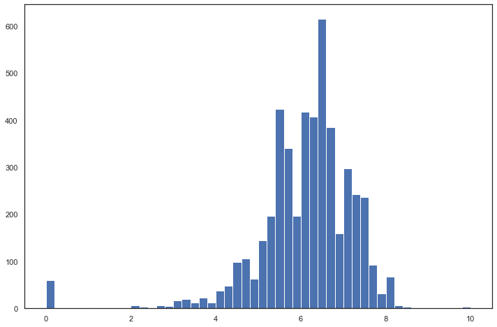

```python
plt.figure(figsize=(12,8))
plt.hist(tmdb_df['vote_average'], bins=50)
```

```python
np.sum(tmdb_df['vote_average']<(tmdb_df['vote_average'].mean()-2*tmdb_df['vote_average'].std()))
```

```
147
```

```python
np.sum(tmdb_df['vote_average']>(tmdb_df['vote_average'].mean()+2*tmdb_df['vote_average'].std()))
```

```
7
```

```python
tmdb_df.sort_values(by=['vote_average'], ascending=False).head(10)
```

|  | id | title | original_language | overview | popularity | release_date | runtime | vote_average | vote_count | cast_num | ... | production_company_0_id | production_company_0_name | production_company_1_id | production_company_1_name | production_countries_num | production_country_code | production_country_name | spoken_languages_num | spoken_language_code | spoken_language_name |
| --- | --- | --- | --- | --- | --- | --- | --- | --- | --- | --- | --- | --- | --- | --- | --- | --- | --- | --- | --- | --- | --- |
| 4043 | 78373 | Dancer, Texas Pop. 81 | en | Four guys, best friends, have grown up togethe... | 0.376662 | 1998-05-01 | 97.0 | 10.0 | 1 | 10 | ... | 4714 | HSX Films | 16517 | Chase Productions | 1 | US | United States of America | 1 | en | English |
| 4242 | 361505 | Me You and Five Bucks | en | A womanizing yet lovable loser, Charlie, a wai... | 0.094105 | 2015-07-07 | 90.0 | 10.0 | 2 | 0 | ... | NaN | None | NaN | None | 0 | NaN | None | 0 | NaN | None |
| 3517 | 89861 | Stiff Upper Lips | en | Stiff Upper Lips is a broad parody of British ... | 0.356495 | 1998-06-12 | 99.0 | 10.0 | 1 | 12 | ... | NaN | None | NaN | None | 2 | GB | United Kingdom | 1 | en | English |
| 3990 | 346081 | Sardaarji | en | A ghost hunter uses bottles to capture trouble... | 0.296981 | 2015-06-26 | 0.0 | 9.5 | 2 | 0 | ... | NaN | None | NaN | None | 1 | IN | India | 0 | NaN | None |
| 2386 | 69848 | One Man's Hero | en | One Man's Hero tells the little-known story of... | 0.910529 | 1999-08-02 | 121.0 | 9.3 | 2 | 15 | ... | 3631 | Filmax | 11601 | Silver Lion Films | 3 | US | United States of America | 1 | en | English |
| 2968 | 88641 | There Goes My Baby | en | A group of high school seniors meets in the su... | 0.037073 | 1994-09-02 | 99.0 | 8.5 | 2 | 9 | ... | 365 | Nelson Entertainment | NaN | None | 1 | US | United States of America | 1 | en | English |
| 1881 | 278 | The Shawshank Redemption | en | Framed in the 1940s for the double murder of h... | 136.747729 | 1994-09-23 | 142.0 | 8.5 | 8205 | 42 | ... | 97 | Castle Rock Entertainment | NaN | None | 1 | US | United States of America | 1 | en | English |
| 3335 | 238 | The Godfather | en | Spanning the years 1945 to 1955, a chronicle o... | 143.659698 | 1972-03-14 | 175.0 | 8.4 | 5893 | 58 | ... | 4 | Paramount Pictures | 10211 | Alfran Productions | 1 | US | United States of America | 3 | en | English |
| 2795 | 43867 | The Prisoner of Zenda | en | An Englishman on a Ruritarian holiday must imp... | 4.021389 | 1937-09-03 | 101.0 | 8.4 | 11 | 12 | ... | 60 | United Artists | 1553 | Selznick International Pictures | 1 | US | United States of America | 2 | es | Español |
| 4743 | 322745 | Counting | en | An associative collection of visual impression... | 0.293587 | 2015-02-09 | 111.0 | 8.3 | 3 | 0 | ... | NaN | None | NaN | None | 1 | US | United States of America | 1 | en | English |

10 rows × 52 columns

### Column 18 - "Vote Count"

```python
tmdb_df['vote_count'].describe()
```

```
count     4791.000000
mean       691.933834
std       1235.654498
min          0.000000
25%         54.500000
50%        237.000000
75%        739.000000
max      13752.000000
Name: vote_count, dtype: float64
```

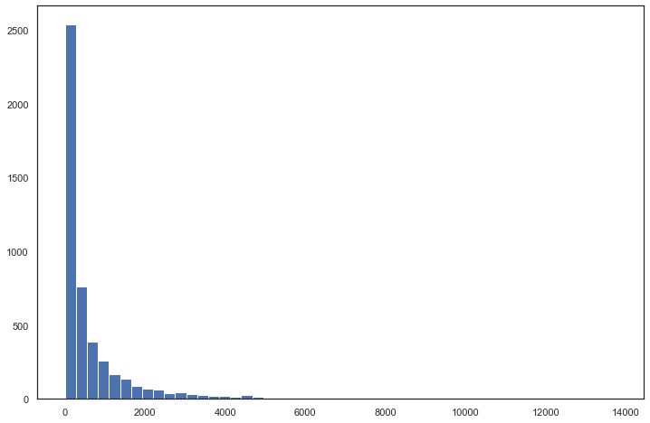

```python
plt.figure(figsize=(12,8))
plt.hist(tmdb_df['vote_count'], bins=50)
```

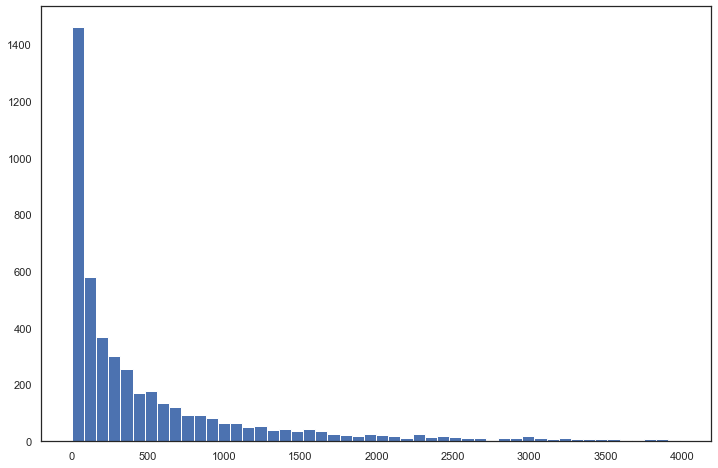

```python
plt.figure(figsize=(12,8))
plt.hist(tmdb_df[tmdb_df['vote_count']<4000]['vote_count'], bins=50)
```

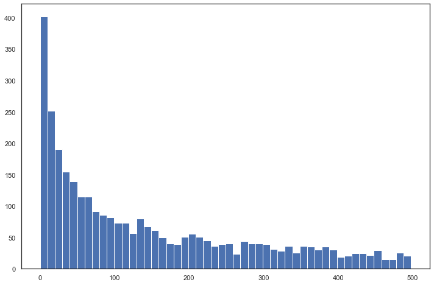

```python
plt.figure(figsize=(12,8))
plt.hist(tmdb_df[tmdb_df['vote_count']<500]['vote_count'], bins=50)
```

```python
np.sum(tmdb_df['vote_count']<50)
```

```
1139
```

```python
np.sum(tmdb_df['vote_count']<10)
```

```
402
```

```python
np.sum(tmdb_df['vote_count']<5)
```

```
237
```

```python
np.sum(tmdb_df['vote_count']<3)
```

```
153
```

```python
tmdb_df.sort_values(by=['vote_count'], ascending=False).head(10)
```

|  | id | title | original_language | overview | popularity | release_date | runtime | vote_average | vote_count | cast_num | ... | production_company_0_id | production_company_0_name | production_company_1_id | production_company_1_name | production_countries_num | production_country_code | production_country_name | spoken_languages_num | spoken_language_code | spoken_language_name |
| --- | --- | --- | --- | --- | --- | --- | --- | --- | --- | --- | --- | --- | --- | --- | --- | --- | --- | --- | --- | --- | --- |
| 96 | 27205 | Inception | en | Cobb, a skilled thief who commits corporate es... | 167.583710 | 2010-07-14 | 148.0 | 8.1 | 13752 | 29 | ... | 923 | Legendary Pictures | 6194 | Warner Bros. | 2 | GB | United Kingdom | 3 | en | English |
| 65 | 155 | The Dark Knight | en | Batman raises the stakes in his war on crime. ... | 187.322927 | 2008-07-16 | 152.0 | 8.2 | 12002 | 134 | ... | 429 | DC Comics | 923 | Legendary Pictures | 2 | GB | United Kingdom | 2 | en | English |
| 0 | 19995 | Avatar | en | In the 22nd century, a paraplegic Marine is di... | 150.437577 | 2009-12-10 | 162.0 | 7.2 | 11800 | 83 | ... | 289 | Ingenious Film Partners | 306 | Twentieth Century Fox Film Corporation | 2 | US | United States of America | 2 | en | English |
| 16 | 24428 | The Avengers | en | When an unexpected enemy emerges and threatens... | 144.448633 | 2012-04-25 | 143.0 | 7.4 | 11776 | 115 | ... | 4 | Paramount Pictures | 420 | Marvel Studios | 1 | US | United States of America | 1 | en | English |
| 788 | 293660 | Deadpool | en | Deadpool tells the origin story of former Spec... | 514.569956 | 2016-02-09 | 108.0 | 7.4 | 10995 | 47 | ... | 306 | Twentieth Century Fox Film Corporation | 7505 | Marvel Entertainment | 1 | US | United States of America | 1 | en | English |
| 95 | 157336 | Interstellar | en | Interstellar chronicles the adventures of a gr... | 724.247784 | 2014-11-05 | 169.0 | 8.1 | 10867 | 36 | ... | 4 | Paramount Pictures | 923 | Legendary Pictures | 3 | CA | Canada | 1 | en | English |
| 287 | 68718 | Django Unchained | en | With the help of a German bounty hunter, a fre... | 82.121691 | 2012-12-25 | 165.0 | 7.8 | 10099 | 115 | ... | 5 | Columbia Pictures | 308 | The Weinstein Company | 1 | US | United States of America | 3 | en | English |
| 94 | 118340 | Guardians of the Galaxy | en | Light years from Earth, 26 years after being a... | 481.098624 | 2014-07-30 | 121.0 | 7.9 | 9742 | 80 | ... | 420 | Marvel Studios | 20478 | Moving Picture Company (MPC) | 2 | GB | United Kingdom | 1 | en | English |
| 426 | 70160 | The Hunger Games | en | Every year in the ruins of what was once North... | 68.550698 | 2012-03-12 | 142.0 | 6.9 | 9455 | 48 | ... | 1632 | Lionsgate | 5420 | Color Force | 1 | US | United States of America | 1 | en | English |
| 127 | 76341 | Mad Max: Fury Road | en | An apocalyptic story set in the furthest reach... | 434.278564 | 2015-05-13 | 120.0 | 7.2 | 9427 | 60 | ... | 79 | Village Roadshow Pictures | 2537 | Kennedy Miller Productions | 2 | AU | Australia | 1 | en | English |

10 rows × 52 columns

Final pitch data and output data

```python
tmdb_df.head()
```

|  | id | title | original_language | overview | popularity | release_date | runtime | vote_average | vote_count | cast_num | ... | production_company_0_id | production_company_0_name | production_company_1_id | production_company_1_name | production_countries_num | production_country_code | production_country_name | spoken_languages_num | spoken_language_code | spoken_language_name |
| --- | --- | --- | --- | --- | --- | --- | --- | --- | --- | --- | --- | --- | --- | --- | --- | --- | --- | --- | --- | --- | --- |
| 0 | 19995 | Avatar | en | In the 22nd century, a paraplegic Marine is di... | 150.437577 | 2009-12-10 | 162.0 | 7.2 | 11800 | 83 | ... | 289 | Ingenious Film Partners | 306 | Twentieth Century Fox Film Corporation | 2 | US | United States of America | 2 | en | English |
| 1 | 285 | Pirates of the Caribbean: At World's End | en | Captain Barbossa, long believed to be dead, ha... | 139.082615 | 2007-05-19 | 169.0 | 6.9 | 4500 | 34 | ... | 2 | Walt Disney Pictures | 130 | Jerry Bruckheimer Films | 1 | US | United States of America | 1 | en | English |
| 2 | 206647 | Spectre | en | A cryptic message from Bond’s past sends him o... | 107.376788 | 2015-10-26 | 148.0 | 6.3 | 4466 | 83 | ... | 5 | Columbia Pictures | 10761 | Danjaq | 2 | GB | United Kingdom | 5 | fr | Français |
| 3 | 49026 | The Dark Knight Rises | en | Following the death of District Attorney Harve... | 112.312950 | 2012-07-16 | 165.0 | 7.6 | 9106 | 158 | ... | 923 | Legendary Pictures | 6194 | Warner Bros. | 1 | US | United States of America | 1 | en | English |
| 4 | 49529 | John Carter | en | John Carter is a war-weary, former military ca... | 43.926995 | 2012-03-07 | 132.0 | 6.1 | 2124 | 27 | ... | 2 | Walt Disney Pictures | NaN | None | 1 | US | United States of America | 1 | en | English |

5 rows × 52 columns

```python
tmdb_df.shape
```

```
(4791, 52)
```

```python
tmdb_df.to_csv('output/data/tmdb_5000_selected.csv', index=False)
```